**Universidad Internacional de La Rioja (UNIR) - Máster Universitario en Inteligencia Artificial - Aprendizaje Automático**

Datos del alumno (Nombre y Apellidos): Jose Manuel Pinillos Rubio

Fecha: 1 de mayo de 2025

# Exploración y comparación de algoritmos de agrupamiento

## Objetivos

Mediante este trabajo se pretende que pongas en práctica la aplicación de los algoritmos de agrupamiento. El objetivo es generar y analizar agrupaciones aplicando algoritmos de aprendizaje máquina, con el fin de elegir el mejor método para el conjunto de datos dado. Debes detallar los pasos que hay que realizar para detección automática de valores inusuales y, por otro lado, analizar los clúster o grupos resultado de aplicar un algoritmo de agrupamiento.

- Entender los métodos de clustering K-means, jerárquico y DBSCAN.
- Generar agrupamientos con los métodos de clustering previamente indicados y realizar una comparativa.
- Investigar sobre una técnica de agrupamiento con un caso de uso concreto.

## Descripción de la actividad

El conjunto de datos con el cual vamos a trabajar se encuentra en el siguiente enlace: https://www.kaggle.com/datasets/umerrtx/machine-failure-prediction-using-sensor-data

Este conjunto de datos contiene datos de sensores recopilados de varias máquinas, con el objetivo de predecir fallos de las máquinas con antelación. Incluye una variedad de lecturas de sensores, así como las fallas de la máquina registradas.

## Tareas que se deben realizar

- **Clustering**:
  - Debes completar el código pedido en este *notebook* y contestar las preguntas finales.
  - Buscar dos artículos científicos (https://scholar.google.es/) con un caso de uso de técnicas de agrupamiento. Los artículos deben estar en revistas científicas, y deben ser posteriores a 2015. No debe utilizar técnicas de Deep Learning.
  - Para cada artículo indicar:
    - Objetivo: cuál es el objetivo de la investigación, es decir a qué problema real está aplicando la detección de anomalías.
    - Técnicas de detección de anomalías empleadas.
    - Principales resultados de la aplicación y de la investigación.

## 1. Análisis exploratorio de los datos

Comenzamos importando las librerías necesarias y cargando el *dataset*.

Este archivo contiene 944 mediciones de sensores de diferentes máquinas, contiene una etiqueta de si tiene fallo o no.

**Notas**:

1. footfall: The number of people or objects passing by the machine.
2. tempMode: The temperature mode or setting of the machine.
3. AQ: Air quality index near the machine.
4. USS: Ultrasonic sensor data, indicating proximity measurements.
5. CS: Current sensor readings, indicating the electrical current usage of the machine.
6. VOC: Volatile organic compounds level detected near the machine.
7. RP: Rotational position or RPM (revolutions per minute) of the machine parts.
8. IP: Input pressure to the machine.
9. Temperature: The operating temperature of the machine.
10. fail: Binary indicator of machine failure (1 for failure, 0 for no failure).

```python
# Librerías básicas
import numpy as np                             # Para operaciones numéricas con arrays y matrices
import pandas as pd                            # Para manipulación y análisis de datos en estructuras tipo DataFrame

# Visualización
import plotly.express as px                    # Para visualizaciones interactivas de alto nivel (gráficos rápidos)
import plotly.graph_objects as go              # Para crear gráficos interactivos personalizados en Plotly
from matplotlib import pyplot as plt           # Para visualizaciones estáticas en 2D
import seaborn as sns                          # Para visualizaciones estadísticas y mapas de calor

# Preprocesamiento y reducción de dimensionalidad
from sklearn.decomposition import PCA             # Para reducción de dimensiones usando Análisis de Componentes Principales
from sklearn.preprocessing import StandardScaler  # Para estandarizar variables numéricas

# Algoritmos de clustering
from sklearn.cluster import AgglomerativeClustering   # Para clustering jerárquico aglomerativo
from sklearn.cluster import DBSCAN                    # Para clustering basado en densidad
from sklearn.cluster import KMeans                    # Para clustering con K-Means

# Evaluación de modelos de clustering
from sklearn.metrics import silhouette_score, silhouette_samples  # Para calcular puntuaciones de silueta
from sklearn.metrics import davies_bouldin_score                  # Para evaluar la cohesión y separación de los clústeres

# Métodos jerárquicos (para dendrogramas)
from scipy.cluster.hierarchy import linkage, dendrogram  # Para generar y visualizar dendrogramas jerárquicos
```

### 1.1 - Cargar el *dataset*

```python
# Importamos el archivo CSV llamado 'data.csv' utilizando como separador la coma (',').
sensors_df = pd.read_csv('data.csv', sep=',')

# Mostramos las 5 primeras filas del DataFrame
sensors_df.head()
```

|  | footfall | tempMode | AQ | USS | CS | VOC | RP | IP | Temperature | fail |
| --- | --- | --- | --- | --- | --- | --- | --- | --- | --- | --- |
| 0 | 0 | 7 | 7 | 1 | 6 | 6 | 36 | 3 | 1 | 1 |
| 1 | 190 | 1 | 3 | 3 | 5 | 1 | 20 | 4 | 1 | 0 |
| 2 | 31 | 7 | 2 | 2 | 6 | 1 | 24 | 6 | 1 | 0 |
| 3 | 83 | 4 | 3 | 4 | 5 | 1 | 28 | 6 | 1 | 0 |
| 4 | 640 | 7 | 5 | 6 | 4 | 0 | 68 | 6 | 1 | 0 |

A continuación, se utiliza el método `.head()` sobre el *DataFrame* para mostrar las primeras cinco filas, lo cual permite realizar una verificación preliminar de que los datos se han importado correctamente y observar la estructura del conjunto.

### 1.2 - ¿Cuántas instancias tiene el *dataset*?

```python
print(f'El dataset tiene {sensors_df.shape[0]} instancias y {sensors_df.shape[1]} atributos.')
```

```
El dataset tiene 944 instancias y 10 atributos.
```

### 1.3 - ¿Cuál es el tipo de datos predominante en el *dataset*?

```python
# Mostramos los tipos de datos de cada columna del DataFrame
sensors_df.dtypes
```

|  | 0 |
| --- | --- |
| footfall | int64 |
| tempMode | int64 |
| AQ | int64 |
| USS | int64 |
| CS | int64 |
| VOC | int64 |
| RP | int64 |
| IP | int64 |
| Temperature | int64 |
| fail | int64 |

**dtype:** object

Esto es solo una forma, ya que si tuviéramos un conjunto con un gran número de atributos, este método no sería el más óptimo. En ese caso, la inspección visual de todos los tipos de datos podría volverse poco práctica y llevar a errores de interpretación si los tipos están muy distribuidos o aparecen con distinta frecuencia.

Por lo tanto, una forma más óptima para acceder a esta información sería:

```python
# Obtenemos la serie con el recuento de tipos de datos
type_counts = sensors_df.dtypes.value_counts()

# Mostramos el tipo de datos predominante junto con su número de repeticiones
print(f'El tipo de datos predominante en el dataset es {type_counts.idxmax()} con un total de {type_counts.max()} repeticiones.')
```

```
El tipo de datos predominante en el dataset es int64 con un total de 10 repeticiones.
```

Este código utiliza el atributo `.dtypes` para obtener los tipos de datos de cada columna, seguido de `.value_counts()` para contar cuántas veces aparece cada tipo. Posteriormente, se utiliza `idxmax()` para recuperar el tipo de dato más frecuente, y `max()` para obtener la cantidad de veces que aparece dicho tipo. Esta aproximación permite identificar de forma precisa y automática el tipo de dato predominante, lo cual resulta especialmente útil en *datasets* de alta dimensionalidad, ya que evita inspecciones manuales propensas a error y facilita un análisis inicial más eficiente y escalable.

### 1.4 - ¿Son variables continuas o categóricas?

```python
# Mostramos un resumen estadístico de los atributos numéricos del DataFrame
sensors_df.describe()
```

|  | footfall | tempMode | AQ | USS | CS | VOC | RP | IP | Temperature | fail |
| --- | --- | --- | --- | --- | --- | --- | --- | --- | --- | --- |
| count | 944.000000 | 944.000000 | 944.000000 | 944.000000 | 944.000000 | 944.000000 | 944.000000 | 944.000000 | 944.000000 | 944.000000 |
| mean | 306.381356 | 3.727754 | 4.325212 | 2.939619 | 5.394068 | 2.842161 | 47.043432 | 4.565678 | 16.331568 | 0.416314 |
| std | 1082.606745 | 2.677235 | 1.438436 | 1.383725 | 1.269349 | 2.273337 | 16.423130 | 1.599287 | 5.974781 | 0.493208 |
| min | 0.000000 | 0.000000 | 1.000000 | 1.000000 | 1.000000 | 0.000000 | 19.000000 | 1.000000 | 1.000000 | 0.000000 |
| 25% | 1.000000 | 1.000000 | 3.000000 | 2.000000 | 5.000000 | 1.000000 | 34.000000 | 3.000000 | 14.000000 | 0.000000 |
| 50% | 22.000000 | 3.000000 | 4.000000 | 3.000000 | 6.000000 | 2.000000 | 44.000000 | 4.000000 | 17.000000 | 0.000000 |
| 75% | 110.000000 | 7.000000 | 6.000000 | 4.000000 | 6.000000 | 5.000000 | 58.000000 | 6.000000 | 21.000000 | 1.000000 |
| max | 7300.000000 | 7.000000 | 7.000000 | 7.000000 | 7.000000 | 6.000000 | 91.000000 | 7.000000 | 24.000000 | 1.000000 |

Observando los estadísticos generados y complementando con la descripción contextual de las variables disponible en la fuente original del *dataset*, se concluye que todas las variables son numéricas, aunque no todas son continuas:

- `footfall`: representa el número de personas u objetos que pasan por la máquina. Presenta un rango amplio (de 0 a 7300), lo cual sugiere que se trata de una variable *continua*.
- `tempMode`, `AQ`, `USS`, `CS`, `VOC`, `IP`: todas estas variables tienen rangos numéricos limitados (por ejemplo, de 0 a 7 o de 1 a 7), lo cual indica que son *numéricas discretas*, a pesar de tener codificación numérica.
- `RP` (rotational position) y `Temperature`: presentan una mayor dispersión y continuidad en los valores, por lo que se consideran *variables continuas*.
- `fail`: es una variable binaria que indica la ocurrencia o no de un fallo. Aunque está codificada numéricamente (0 o 1), en este contexto se interpreta como *variable categórica discreta* o *booleana*.

Esta distinción es importante para elegir las técnicas adecuadas de *preprocesamiento* y para interpretar correctamente los resultados de los algoritmos de *clustering*, ya que algunos métodos pueden verse afectados por la escala o la naturaleza de las variables incluidas.

### 1.5 - ¿cuáles son los valores mínimo y máximo de la variable 'RP'?

Como se mostró previamente en el resumen estadístico, la variable `RP` presenta un valor mínimo de 19 y un valor máximo de 91. Esta información se puede obtener también de forma directa utilizando los métodos `.min()` y `.max()` sobre la columna correspondiente, lo que permite confirmar y recuperar puntualmente los valores extremos de cualquier atributo sin necesidad de analizar todo el *DataFrame*. Esta forma resulta más eficiente cuando se desea consultar rápidamente una sola variable.

```python
# Mostramos el valor mínimo y máximo de la variable RP
print(f'El mínimo de la variable RP es {sensors_df["RP"].min()} y el máximo {sensors_df["RP"].max()}')
```

```
El mínimo de la variable RP es 19 y el máximo 91
```

### 1.6 - Para los algoritmos de clustering el *dataset* no puede tener instancias con datos faltantes. ¿Tiene este *dataset* datos faltantes?

```python
# Calculamos el número de valores nulos por columna
null_values = sensors_df.isna().sum()

# Mostramos las columnas con sus respectivos valores nulos
print(null_values)

# Verificamos si existe al menos un valor nulo en todo el dataset
if sensors_df.isna().values.any():
  print("\nExisten valores nulos en el dataset.")
else:
  print("\nNo existen valores nulos en el dataset.")
```

```
footfall       0
tempMode       0
AQ             0
USS            0
CS             0
VOC            0
RP             0
IP             0
Temperature    0
fail           0
dtype: int64

No existen valores nulos en el dataset.
```

El código comienza calculando el número de valores nulos por columna en el *DataFrame* `sensors_df`. Para ello, se utiliza el método `.isna()`, que genera una estructura booleana en la que cada celda contiene `True` si el valor es nulo y `False` en caso contrario. A continuación, se aplica `.sum()` sobre esa estructura para obtener el total de valores nulos por columna, y estos resultados se almacenan en la variable `null_values`.

Seguidamente, se imprime el contenido de `null_values`, lo cual permite identificar de forma explícita si existe alguna columna con datos faltantes, y en qué magnitud. Esta verificación es esencial para decidir si es necesario aplicar técnicas de imputación o eliminación de instancias.

Finalmente, se realiza una comprobación global sobre el *DataFrame* completo. La combinación de `.values.any()` evalúa si existe al menos un valor `True` en el conjunto booleano generado por `.isna()`, es decir, si hay al menos un valor nulo en todo el *dataset*. Dependiendo del resultado, se imprime un mensaje indicando si los datos están completos o si existen valores faltantes que deban ser tratados antes de aplicar algoritmos de *clustering*.

Se comprueba que no existen valores nulos en el *dataset*. Por tanto, no es necesario aplicar técnicas de imputación ni eliminar instancias, y se puede proceder con los algoritmos de agrupamiento sin restricciones por datos faltantes.

### 1.7 - Elimine la variable fail

```python
# Eliminamos la columna 'fail' del DataFrame
sensors_df.drop(['fail'], axis=1, inplace=True)

# Mostramos las 5 primeras filas del DataFrame resultante
sensors_df.head()
```

|  | footfall | tempMode | AQ | USS | CS | VOC | RP | IP | Temperature |
| --- | --- | --- | --- | --- | --- | --- | --- | --- | --- |
| 0 | 0 | 7 | 7 | 1 | 6 | 6 | 36 | 3 | 1 |
| 1 | 190 | 1 | 3 | 3 | 5 | 1 | 20 | 4 | 1 |
| 2 | 31 | 7 | 2 | 2 | 6 | 1 | 24 | 6 | 1 |
| 3 | 83 | 4 | 3 | 4 | 5 | 1 | 28 | 6 | 1 |
| 4 | 640 | 7 | 5 | 6 | 4 | 0 | 68 | 6 | 1 |

El código elimina la columna `fail` del *DataFrame* `sensors_df` utilizando el método `.drop()`. Para ello, se especifica el nombre de la columna entre corchetes, se indica `axis=1` para señalar que la operación se realiza sobre columnas (también podría haberse utilizado `axis='columns'`), y se añade el parámetro `inplace=True` para que la eliminación se aplique directamente sobre el *DataFrame* original, sin necesidad de reasignarlo.

A continuación, se utiliza el método `.head()` para mostrar las primeras cinco filas del *DataFrame* resultante. Esto permite comprobar que la columna ha sido efectivamente eliminada y que la estructura del conjunto de datos ha sido actualizada correctamente.

### 1.8 - ¿Es necesario hacer algún tratamiendo adicional sobre los datos?

Aunque todas las variables del *dataset* son numéricas, sus escalas varían considerablemente. Por ejemplo, `footfall` tiene un rango que alcanza hasta 7300, mientras que variables como `USS` o `VOC` oscilan entre 0 y 7. Esta disparidad puede afectar negativamente a los algoritmos de *clustering* basados en distancia, como *K-Means* o *DBSCAN*, ya que las variables con mayor magnitud tienden a dominar el cálculo de distancias, sesgando los resultados.

Por tanto, sí es necesario aplicar un tratamiento adicional: normalizar o estandarizar los datos. Esta transformación garantiza que todas las variables contribuyan de forma equilibrada al proceso de agrupamiento, sin que ninguna de ellas tenga un peso desproporcionado debido a su escala. Con ello, se mejora la eficacia y la estabilidad de los algoritmos de agrupamiento.

En la práctica, tanto *K-Means* como *DBSCAN* requieren que los datos estén en una escala común para funcionar correctamente, por lo que es habitual aplicar alguna técnica de escalado antes del agrupamiento. Sin embargo, para tomar una decisión bien fundamentada entre normalizar (reducir a un rango como [0,1]) o estandarizar (centrar en cero y escalar a varianza uno), es importante conocer primero la forma de distribución de los datos.

Para ello, se generarán histogramas de todas las variables del *dataset* para analizar de forma exploratoria la simetría, la presencia de sesgos o valores atípicos, y la continuidad o discreción de cada variable. A partir de este análisis, podremos justificar técnicamente qué técnica de escalado resulta más adecuada para preparar los datos antes de aplicar los algoritmos de *clustering*.

#### 1.8.1 - Análisis exploratorio de simetrías

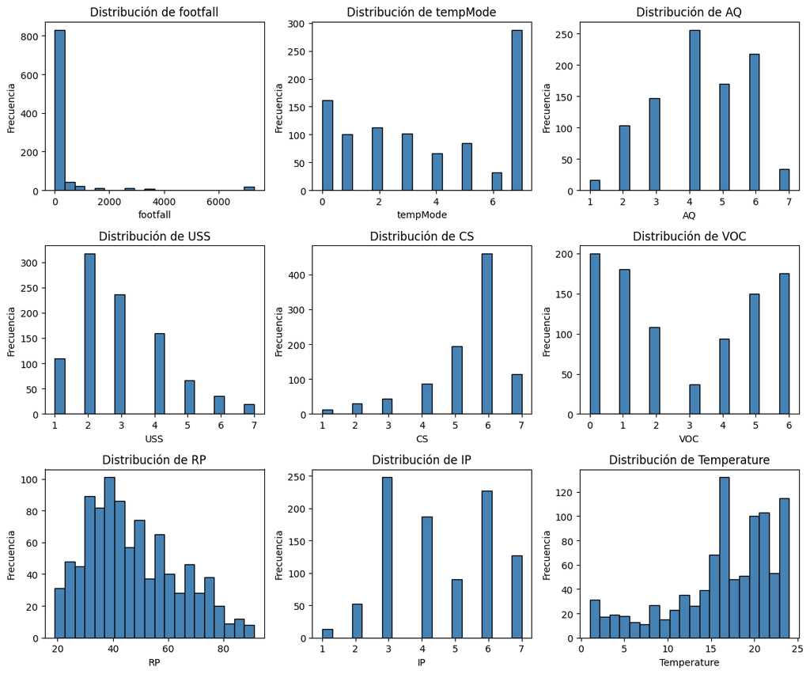

```python
# Definimos el tamaño de la figura y la estructura de subgráficos 3x3
fig, axes = plt.subplots(nrows=3, ncols=3, figsize=(12, 10))

# Convertimos los ejes en una lista para iterar fácilmente
axes = axes.flatten()

# Iteramos sobre las columnas del DataFrame y dibujamos un histograma por variable
for i, column in enumerate(sensors_df.columns):
    sensors_df[column].plot.hist(ax=axes[i], bins=20, color='steelblue', edgecolor='black')
    axes[i].set_title(f'Distribución de {column}')
    axes[i].set_xlabel(column)
    axes[i].set_ylabel('Frecuencia')

# Ajustamos el espaciado entre subgráficos
plt.tight_layout()

# Mostramos la figura con todos los histogramas
plt.show()
```

El código comienza generando una figura compuesta por nueve subgráficos dispuestos en una cuadrícula de 3x3, con el objetivo de representar visualmente la distribución de todas las variables numéricas del *DataFrame* `sensors_df`. Para ello, se utiliza la función `plt.subplots`, donde se establece el tamaño total de la figura mediante el parámetro `figsize`, lo que garantiza una presentación clara y proporcionada. A continuación, los ejes generados se convierten en una lista unidimensional con `.flatten()` para facilitar la iteración posterior.

Seguidamente, se recorre cada columna del *DataFrame* mediante un bucle `for` y se dibuja su correspondiente histograma utilizando `plot.hist()`. Se especifica un número fijo de intervalos (`bins=20`), así como el color de las barras (`steelblue`) y sus bordes (`black`) para asegurar una buena legibilidad. Cada gráfico incluye un título, y etiquetas para los ejes X e Y que indican la variable representada y su frecuencia, respectivamente. Tras la creación de los nueve histogramas, se utiliza `plt.tight_layout()` para ajustar automáticamente los espacios entre subgráficos y evitar solapamientos, y finalmente se muestra el conjunto completo con `plt.show()`.

Los resultados obtenidos revelan una gran heterogeneidad en las distribuciones de las variables. Algunas, como `RP`, muestran una forma cercana a una distribución normal. Otras, como `Temperature` o `CS`, presentan cierto grado de simetría, aunque con sesgos evidentes. En cambio, variables como `footfall` presentan una fuerte asimetría positiva, con valores concentrados en el extremo inferior del rango y la presencia clara de valores atípicos. El resto de variables, como `USS`, `VOC`, `AQ` o `IP`, presentan distribuciones discretas con patrones irregulares, lo que confirma que el conjunto de datos no está compuesto por variables que compartan una estructura de distribución homogénea ni por escalas equivalentes.

Dado que los datos obtenidos muestran rangos dispares y distribuciones no necesariamente normales, se decide aplicar una estandarización como técnica de preprocesamiento. Esta elección se justifica por su capacidad para centrar los datos en cero y escalar su varianza a uno, independientemente de la forma de su distribución original. La estandarización permite que cada variable contribuya de forma equitativa al cálculo de distancias, lo cual es esencial en algoritmos como *K-Means* o *DBSCAN*, que se basan en distancias. Se trata, por tanto, de una decisión metodológicamente adecuada que garantiza la comparabilidad entre variables y mejora la calidad de los resultados de agrupamiento.

#### 1.8.2 - Estandarización de los datos

```python
# Creamos una copia del DataFrame original para mantenerlo intacto
sensors_df_fit = sensors_df.copy()

# Instanciamos el escalador estándar
scaler = StandardScaler()

# Aplicamos StandardScaler y convertimos el resultado a DataFrame
sensors_df_fit = pd.DataFrame(scaler.fit_transform(sensors_df_fit), columns=sensors_df.columns)

# Mostramos las primeras filas del dataset estandarizado
print("Dataset original escalado:")
display(sensors_df_fit.head())
```

```
Dataset original escalado:
```

|  | footfall | tempMode | AQ | USS | CS | VOC | RP | IP | Temperature |
| --- | --- | --- | --- | --- | --- | --- | --- | --- | --- |
| 0 | -0.283153 | 1.222896 | 1.860497 | -1.402480 | 0.477610 | 1.389813 | -0.672788 | -0.979504 | -2.567407 |
| 1 | -0.107558 | -1.019410 | -0.921775 | 0.043660 | -0.310613 | -0.810763 | -1.647540 | -0.353894 | -2.567407 |
| 2 | -0.254504 | 1.222896 | -1.617343 | -0.679410 | 0.477610 | -0.810763 | -1.403852 | 0.897327 | -2.567407 |
| 3 | -0.206446 | 0.101743 | -0.921775 | 0.766730 | -0.310613 | -0.810763 | -1.160164 | 0.897327 | -2.567407 |
| 4 | 0.308326 | 1.222896 | 0.469361 | 2.212869 | -1.098836 | -1.250878 | 1.276716 | 0.897327 | -2.567407 |

El código comienza importando la clase `StandardScaler` de la librería `sklearn.preprocessing`, que permite estandarizar los datos numéricos para que todas las variables tengan media cero y desviación estándar uno. A continuación, se crea una copia del *DataFrame* original `sensors_df` mediante el método `.copy()`, con el objetivo de preservar los datos originales intactos y evitar modificaciones accidentales durante el procesamiento.

Posteriormente, se instancia el objeto escalador con `StandardScaler()`, y se aplica sobre el conjunto completo de datos con el método `fit_transform()`. Esta operación realiza dos acciones: calcula los parámetros de media y desviación estándar para cada variable (`fit`), y transforma los datos según esos parámetros (`transform`). El resultado es un `numpy.ndarray`, por lo que se convierte explícitamente en un nuevo *DataFrame* con `pd.DataFrame(...)`, asegurando que se mantengan los nombres originales de las columnas mediante el argumento `columns=sensors_df.columns`.

Finalmente, se utiliza `display()` junto a `.head()` para mostrar las primeras cinco filas del *DataFrame* resultante. Esto permite verificar visualmente que los valores han sido correctamente estandarizados y que la estructura del conjunto de datos se ha conservado tras la transformación. Esta operación es esencial para garantizar que las variables contribuyan de forma equilibrada a los algoritmos de *clustering*.

## 2. K-Means

### 2.1 - Crea 10 modelos de K-Means y entrénalos. Haciendo uso del método indicado para saber el número ideal de clústeres.

A continuación se entrenará una serie de modelos de *K-Means* con diferentes valores de $k$, con el objetivo de identificar el número óptimo de clústeres para aplicar el algoritmo de agrupamiento al conjunto de datos estandarizado. Para ello, se aplicarán dos métodos complementarios: el **método del codo**, que evalúa la variación de la inercia (suma de las distancias cuadradas entre los puntos y sus respectivos centroides), y el **coeficiente de silueta**, que mide el grado de cohesión y separación entre los grupos formados. Esta combinación permite analizar tanto la cohesión interna de los clústeres como la heterogeneidad entre ellos, aportando un criterio más equilibrado y fundamentado para determinar el valor óptimo de $k$.

El experimento se realizará entrenando diez modelos diferentes, desde $k=2$ hasta $k=11$, utilizando la implementación de *K-Means* disponible en la librería *scikit-learn*. Esta versión permite seleccionar entre dos métodos de inicialización de centroides: *random* y *K-Means++*, siendo este último el elegido en este caso por ofrecer una distribución inicial más eficiente y estable.

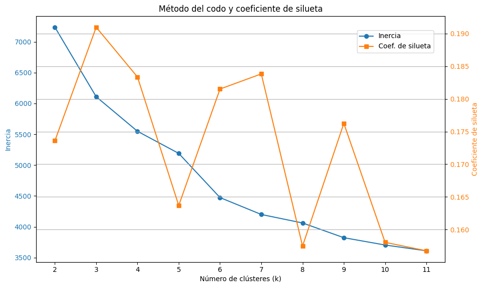

```python
# Definimos un rango de valores de k desde 2 hasta 11
k_range = range(2, 12)

# Inicializamos listas para guardar las métricas de evaluación
inertias = []
silhouette_scores = []

# Entrenamos un modelo de K-Means para cada valor de k y calculamos las métricas
for k in k_range:
    kmeans = KMeans(n_clusters=k, init='k-means++', random_state=42)
    kmeans.fit(sensors_df_fit)

    # Guardamos la inercia del modelo
    inertias.append(kmeans.inertia_)

    # Calculamos y almacenamos el coeficiente de silueta
    score = silhouette_score(sensors_df_fit, kmeans.labels_)
    silhouette_scores.append(score)

# Representamos ambas métricas en un gráfico conjunto
fig, ax1 = plt.subplots(figsize=(10, 6))

# Curva del método del codo (inercia)
line1, = ax1.plot(k_range, inertias, marker='o', label='Inercia', color='tab:blue')
ax1.set_xlabel('Número de clústeres (k)')
ax1.set_ylabel('Inercia', color='tab:blue')
ax1.tick_params(axis='y', labelcolor='tab:blue')

# Segunda escala para el coeficiente de silueta
ax2 = ax1.twinx()
line2, = ax2.plot(k_range, silhouette_scores, marker='s', label='Coef. de silueta', color='tab:orange')
ax2.set_ylabel('Coeficiente de silueta', color='tab:orange')
ax2.tick_params(axis='y', labelcolor='tab:orange')

# Añadimos una leyenda fuera de la gráfica, con recuadro
fig.legend(handles=[line1, line2], loc='upper right', bbox_to_anchor=(0.9, 0.90), ncol=1, frameon=True)
# Título, rejilla y ajuste del diseño
plt.title('Método del codo y coeficiente de silueta')
plt.grid(True)
plt.xticks(k_range)
plt.tight_layout()
plt.show()
```

El código comienza importando las funciones necesarias para aplicar el algoritmo *K-Means* (`KMeans`) y para calcular el coeficiente de silueta (`silhouette_score`). A continuación, se define un rango de valores para el número de clústeres (`k`) desde 2 hasta 11, ya que el coeficiente de silueta no es aplicable cuando solo se forma un único clúster. Se inicializan dos listas vacías (`inertias` y `silhouette_scores`) donde se almacenarán las métricas correspondientes a cada modelo entrenado.

Dentro del bucle `for`, se entrena un modelo de *K-Means* para cada valor de $k$, utilizando el método de inicialización *K-Means++* y fijando la semilla aleatoria en 42 para asegurar la reproducibilidad. Una vez entrenado el modelo, se almacena la inercia (medida de compactación interna) mediante el atributo `.inertia_`, y se calcula el coeficiente de silueta a partir de las etiquetas asignadas por el modelo. Esta métrica evalúa la calidad del agrupamiento considerando tanto la cohesión dentro de los clústeres como su separación respecto a los demás.

Después del entrenamiento, se representa gráficamente la evolución de ambas métricas. Para ello, se crea una figura con dos ejes verticales mediante `twinx()`: uno para mostrar la inercia (a la izquierda) y otro para el coeficiente de silueta (a la derecha). Cada curva se dibuja con su estilo y color correspondiente, y se incluye una leyenda situada en la parte superior derecha dentro del área del gráfico, con recuadro, para facilitar la identificación visual de ambas métricas. Finalmente, se aplican algunos ajustes estéticos como el título, el espaciado (`tight_layout`), la rejilla y las marcas del eje X.

El gráfico resultante permite visualizar de forma conjunta cómo evolucionan la inercia y el coeficiente de silueta a medida que se incrementa el número de clústeres. Como es esperable, la inercia disminuye de forma progresiva conforme aumenta $k$, indicando una mayor compactación interna. No obstante, el método del codo no muestra un punto de inflexión claramente definido, aunque puede intuirse una ligera desaceleración en la caída de la inercia a partir de $k = 6$.

En cuanto al coeficiente de silueta, se observa una mayor variabilidad: alcanza su valor más alto en $k = 3$, lo que sugiere una segmentación con buena cohesión interna y separación entre grupos en ese punto. A partir de ahí, el coeficiente presenta oscilaciones, con valores relativamente altos también en $k = 6$ y $k = 9$, mientras que para otros valores como $k = 5$, $k = 8$ o $k = 10$ disminuye de forma notable, indicando posibles solapamientos o estructuras menos definidas.

Dado que los resultados no apuntan a un único valor óptimo y tanto la inercia como el coeficiente de silueta presentan patrones variables, se representarán visualmente los clústeres generados para valores de $k$ igual a 3, 4, 6 y 7. Esta comparación permitirá observar de forma más directa la coherencia interna, la separación entre grupos y la posible estructura subyacente en el espacio reducido, lo que facilitará una elección más fundamentada del número definitivo de clústeres.

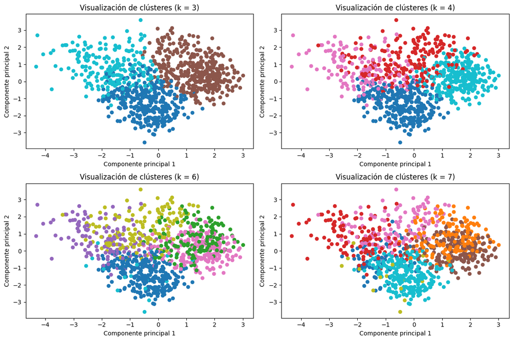

```python
# Aplicamos PCA para reducir a 2 dimensiones los datos estandarizados
pca = PCA(n_components=2)
pca_components = pca.fit_transform(sensors_df_fit)

# Definimos los valores de k que queremos visualizar
k_values = [3, 4, 6, 7]

# Creamos una figura con subgráficos
fig, axes = plt.subplots(2, 2, figsize=(12, 8))
axes = axes.flatten()

# Entrenamos un modelo K-Means para cada valor de k y graficamos los clústeres
for i, k in enumerate(k_values):
    kmeans = KMeans(n_clusters=k, init='k-means++', random_state=42)
    clusters = kmeans.fit_predict(sensors_df_fit)

    # Graficamos los clústeres en el espacio reducido por PCA
    scatter = axes[i].scatter(pca_components[:, 0], pca_components[:, 1], c=clusters, cmap='tab10', s=30)
    axes[i].set_title(f'Visualización de clústeres (k = {k})')
    axes[i].set_xlabel('Componente principal 1')
    axes[i].set_ylabel('Componente principal 2')

# Ajustamos el diseño de la figura
plt.tight_layout()
plt.show()
```

El código comienza importando la clase `PCA` de la librería `sklearn.decomposition`, utilizada para reducir la dimensionalidad del conjunto de datos estandarizado. Se aplica una reducción a dos componentes principales (`n_components=2`) mediante el método `.fit_transform()`, lo que permite proyectar los datos en un espacio bidimensional que conserva la mayor cantidad posible de varianza. El resultado se almacena en la variable `pca_components`, que se utilizará como base para la representación gráfica.

A continuación, se define una lista con los valores de *k* seleccionados para la visualización de los clústeres: 3, 4, 6 y 7. Estos valores han sido elegidos previamente en función de los resultados obtenidos con las métricas de evaluación y el análisis exploratorio.

Se crea una figura compuesta por subgráficos organizados en una cuadrícula de 2 filas por 2 columnas (`figsize=(12, 8)`), lo que permite representar simultáneamente las agrupaciones correspondientes a cada valor de *k*. Con `axes.flatten()` se transforma la estructura de subgráficos en una lista para facilitar la iteración.

Dentro del bucle `for`, se entrena un modelo de *K-Means* para cada uno de los valores de *k* especificados, utilizando inicialización *K-Means++* y semilla fija. Una vez entrenado, se obtienen las etiquetas asignadas a cada instancia mediante `kmeans.fit_predict()` y se representan los clústeres proyectados sobre las dos primeras componentes principales obtenidas con PCA. Para ello, se utiliza el método `.scatter()` sobre el subgráfico correspondiente, asignando un color distinto a cada clúster mediante el parámetro `cmap='tab10'`.

Finalmente, se ajusta automáticamente la distribución de los subgráficos con `plt.tight_layout()` para evitar solapamientos entre títulos y etiquetas, y se muestra la figura completa con `plt.show()`. Esta visualización permite comparar de forma directa cómo varían las agrupaciones al modificar el número de clústeres.

A partir de la visualización de los clústeres proyectados en el espacio de las dos primeras componentes principales, se aprecia que para $k = 3$ los grupos formados presentan una estructura clara, bien separada y con fronteras visualmente definidas. Esta configuración es coherente con el valor más alto observado en el coeficiente de silueta, lo que sugiere una buena cohesión interna y una separación adecuada entre clústeres.

Cuando se incrementa el número de grupos a $k = 4$, se observa una subdivisión de regiones previas sin una mejora evidente en la estructura general, comenzando a aparecer cierta superposición entre clústeres. Esta tendencia se acentúa en $k = 6$ y $k = 7$, donde la separación entre grupos es menos evidente y la distribución resulta más dispersa y fragmentada, lo que indica una posible pérdida de significado en la segmentación.

Por tanto, se concluye que $k = 3$ representa la opción más adecuada para este conjunto de datos, al ofrecer un equilibrio óptimo entre simplicidad, cohesión y separación, tanto desde el punto de vista cuantitativo como visual.

### 2.2 - Interpretación de datos

Ahora toca interpretar lo que Kmeans ha realizado. Recordemos que el objetivo de KMeans es encontrar patrones en los datos.

Lo primero que vamos a realizar es un gráfico para visualizar los clústers que ha creado con base en las variables utilizadas para crearlos.

```python
# Creamos un nuevo modelo KMeans con k=3 y entrenamos sobre los datos estandarizados
kmeans_model = KMeans(n_clusters=3, init='k-means++', random_state=42)
kmeans_model.fit(sensors_df_fit)

# Creamos un DataFrame con los datos estandarizados y las etiquetas asignadas
clusters_kmeans = pd.DataFrame(sensors_df_fit,columns=sensors_df.columns)
clusters_kmeans['label'] = kmeans_model.labels_

# Calculamos la media de cada variable por clúster
polar_kmeans = clusters_kmeans.groupby("label").mean().reset_index()

# Transformamos los datos a formato largo para el gráfico polar
polar_kmeans = pd.melt(polar_kmeans,id_vars=["label"])

# Generamos el gráfico polar con Plotly
fig4 = px.line_polar(polar_kmeans,
                     r="value",
                     theta="variable",
                     color="label",
                     line_close=True,
                     height=800,width=800)
fig4.show()
```

[figure not shown]

El código comienza creando un modelo de *K-Means* con tres clústeres utilizando el método de inicialización *K-Means++* y una semilla aleatoria fijada en 42 para asegurar la reproducibilidad. A continuación, se entrena el modelo sobre los datos previamente estandarizados (`sensors_df_fit`) mediante el método `.fit()`, lo que permite asignar cada instancia del conjunto a uno de los tres clústeres generados.

Posteriormente, se calcula la media de cada variable dentro de cada clúster mediante `.groupby("label").mean()` y se aplica `reset_index()` para preparar el *DataFrame* para una visualización posterior. Esto da lugar a un resumen numérico que describe el comportamiento medio de cada grupo en todas las variables estandarizadas.

El *DataFrame* resultante se transforma a formato largo utilizando `pd.melt()`, lo que permite que cada fila represente una combinación entre una variable y un clúster. Este formato es necesario para poder generar el gráfico polar, que se construye mediante `px.line_polar()`. En él, cada línea representa el perfil medio de un clúster sobre el conjunto completo de variables. Se utiliza `line_close=True` para cerrar las líneas formando polígonos y se especifica el tamaño de la figura con `height` y `width` para garantizar una visualización clara y proporcionada. Finalmente, el gráfico se muestra con `fig4.show()`.

El gráfico polar representa de forma visual el comportamiento medio de cada uno de los clústeres obtenidos mediante *K-Means* sobre las variables estandarizadas. Cada línea corresponde a uno de los tres clústeres generados, y el recorrido de esa línea sobre cada eje radial indica la media del clúster correspondiente en esa variable. Al estar los datos estandarizados, el valor cero representa la media global del conjunto, mientras que los valores positivos o negativos indican desviaciones respecto a esa media.

Por su parte, el **clúster 0** muestra un perfil más contenido, sin extremos muy marcados. Tiende a valores negativos en `AQ` y `VOC`, lo que podría asociarse a condiciones ambientales favorables, mientras que en `CS` presenta una elevación visible, indicando un consumo de corriente algo más elevado. El resto de variables oscilan en torno a la media, lo que sugiere un patrón operativo más equilibrado.

En conjunto, el gráfico polar permite visualizar de forma clara cómo cada clúster se posiciona en relación con las distintas variables. Las diferencias en la forma y amplitud de cada línea ayudan a identificar qué dimensiones son más discriminativas entre grupos, y qué combinaciones de características definen a cada segmento dentro del conjunto analizado. Esta visualización proporciona una vista general muy útil para comparar perfiles de comportamiento entre los grupos identificados.

Aunque el gráfico es interactivo y permite consultar los valores concretos de cada punto, puede resultar menos práctico cuando se necesita revisar o comunicar los resultados en formato estático. Por este motivo, se crea a continuación una tabla resumen que recoge las medias estandarizadas por clúster, lo que facilita la comparación precisa de las variables entre grupos y permite identificar más fácilmente los atributos dominantes en cada uno de ellos.

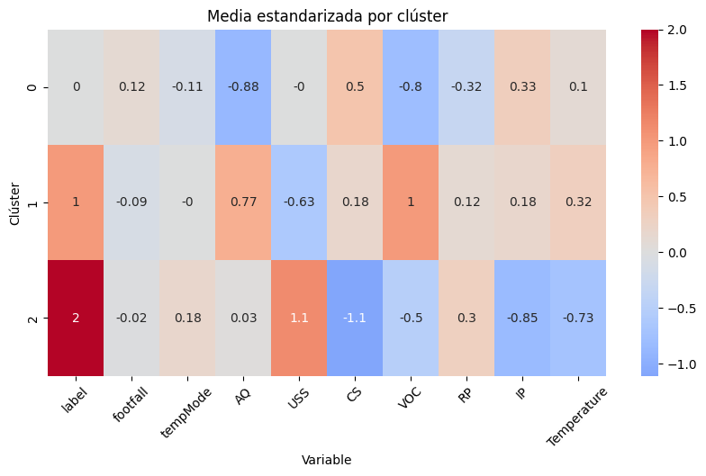

```python
# Calculamos la media de cada variable por clúster y lo mostramos como DataFrame
cluster_means = clusters_kmeans.groupby("label").mean().round(2).reset_index()

# Visualizamos como heatmap
plt.figure(figsize=(10, 5))
sns.heatmap(cluster_means, annot=True, cmap="coolwarm", center=0)
plt.title("Media estandarizada por clúster")
plt.ylabel("Clúster")
plt.xlabel("Variable")
plt.xticks(rotation=45)
plt.show()
```

Una vez creada la tabla, se visualiza mediante un *heatmap* utilizando `seaborn`. Se establece un tamaño fijo de figura y se llama a `sns.heatmap()` pasando como argumento el *DataFrame* `cluster_means`, activando la anotación de los valores (`annot=True`) y utilizando el mapa de colores `"coolwarm"` con el centro en cero (`center=0`). Esto permite representar en escala cromática la desviación de cada valor respecto a la media global: los valores positivos se muestran en tonos cálidos (rojos), y los negativos en tonos fríos (azules). Se rotan las etiquetas del eje X 45 grados para mejorar la legibilidad, y se añaden título y etiquetas para los ejes.

Este gráfico complementa directamente la visualización anterior en el gráfico polar, ya que los datos que alimentan ambas representaciones son los mismos: las medias estandarizadas por clúster. No obstante, a diferencia del polar, el *heatmap* permite observar de forma precisa los valores numéricos, lo que resulta especialmente útil para análisis comparativos o documentación. Además, la intensidad del color ayuda a identificar rápidamente en qué variables se concentran las mayores diferencias entre grupos, lo que refuerza la interpretación visual de los perfiles detectados.

### 2.3 - Interpretación operativa y perfilado funcional de los clústeres

El primer grupo, que denominaremos **"clúster ambientalmente favorable"**, agrupa a aquellas máquinas que operan en condiciones externas más limpias, con niveles bajos de compuestos volátiles y buena calidad del aire. Su consumo eléctrico es moderado y presentan un comportamiento bastante equilibrado en el resto de variables, lo que sugiere que se trata de un segmento estable y menos exigente desde el punto de vista operativo.

El segundo grupo, al que podríamos llamar **"clúster de entorno agresivo"**, está compuesto por máquinas que muestran valores significativamente elevados en `VOC` y `AQ`, indicadores que apuntan a un entorno más contaminado o con una atmósfera cargada. También se detectan niveles ligeramente más altos en temperatura y consumo eléctrico, lo que sugiere que estas unidades podrían estar expuestas a condiciones más severas o a una carga de trabajo superior. Este clúster representa un grupo de especial interés, ya que podría estar más expuesto a fallos o requerir estrategias de mantenimiento preventivo más frecuentes.

## 3. DBSCAN

### 3.1 - Realiza una búsqueda de los mejores hiperparámetros para el algoritmo

Antes de comenzar con la aplicación del algoritmo DBSCAN, es necesario comprender los hiperparámetros que ofrece su implementación en *scikit-learn*. A diferencia de otros algoritmos como *K-Means*, DBSCAN no requiere que se indique el número de clústeres previamente, sino que detecta agrupamientos en función de la densidad de los datos. Para lograrlo, utiliza una serie de parámetros que condicionan directamente el número de clústeres detectados, su forma y la sensibilidad al ruido. A continuación se describen los principales hiperparámetros que se deben considerar para ajustar correctamente este modelo:

#### `eps`

El hiperparámetro `eps` (epsilón) define el radio máximo que se considerará para evaluar la vecindad de un punto. Es decir, indica hasta qué distancia se buscarán otros puntos vecinos alrededor de una muestra dada. Si el número de puntos dentro de ese radio cumple con el mínimo requerido (`min_samples`), el punto se considerará parte de una región densa y, por tanto, será incluido en un clúster.

Valores bajos de `eps` generan clústeres más pequeños y fragmentados, ya que se requiere una cercanía muy estricta para considerar que los puntos están agrupados. En cambio, valores altos tienden a unir regiones más amplias y reducir la cantidad de puntos considerados como ruido, lo que puede provocar agrupaciones menos precisas. La elección de este parámetro es clave para el buen funcionamiento del algoritmo y suele determinar la estructura final del agrupamiento.

#### `min_samples`

El hiperparámetro `min_samples` especifica el número mínimo de puntos necesarios dentro de una vecindad (definida por `eps`) para que un punto se considere un núcleo. Si un punto tiene al menos `min_samples` vecinos dentro del radio `eps`, entonces ese punto se convierte en el centro de un clúster. Los puntos que no cumplen esta condición pueden ser clasificados como frontera (si están cerca de un núcleo) o como ruido (si no cumplen ninguna de las condiciones).

Un valor bajo para `min_samples` permite detectar estructuras más pequeñas y localizar agrupamientos en regiones menos densas, pero aumenta la sensibilidad al ruido. En cambio, un valor alto favorece clústeres más compactos y robustos, aunque puede dejar fuera puntos válidos y reducir el número total de agrupamientos detectados.

#### `metric`

El hiperparámetro `metric` determina la función de distancia utilizada para calcular la cercanía entre los puntos. Por defecto, se emplea la distancia euclídea (`'euclidean'`), pero también se pueden utilizar otras métricas como `'manhattan'`, `'cosine'` o `'chebyshev'`, entre otras. La elección de la métrica puede influir considerablemente en la forma y composición de los clústeres, especialmente en datasets donde la geometría o la escala de las variables presenta particularidades.

Seleccionar una métrica distinta puede resultar útil en contextos donde las variables no están en la misma escala o cuando se desea capturar una noción de similitud diferente a la puramente geométrica.

#### `algorithm`

El hiperparámetro `algorithm` define el método que se utilizará para encontrar los vecinos dentro del radio `eps`. Las opciones disponibles son `'auto'`, `'ball_tree'`, `'kd_tree'` y `'brute'`. Por defecto se utiliza `'auto'`, que selecciona la mejor opción según las características del conjunto de datos. Este parámetro no afecta al resultado del agrupamiento, pero sí puede impactar en el tiempo de ejecución, especialmente en datasets grandes.

#### `leaf_size`

El parámetro `leaf_size` se utiliza cuando se selecciona `'ball_tree'` o `'kd_tree'` como algoritmo. Define el tamaño de las hojas en la estructura del árbol de vecinos. Aunque no altera los clústeres generados, puede afectar al rendimiento computacional y al uso de memoria, por lo que puede ajustarse en casos donde se requiere optimización de velocidad.

#### `n_jobs`

El hiperparámetro `n_jobs` controla el número de procesadores que se utilizarán para ejecutar el algoritmo. Si se establece en `-1`, se utilizarán todos los núcleos disponibles. Este parámetro no modifica el resultado del clustering, pero sí puede reducir significativamente el tiempo de ejecución en entornos con múltiples núcleos.

Una vez conocidos los hiperparámetros principales del modelo, se concluye que en problemas como el actual es recomendable centrarse en la búsqueda conjunta de valores adecuados para `eps` y `min_samples`, ya que son los que definen la estructura del agrupamiento y la sensibilidad del algoritmo al ruido. Aunque en otros modelos sería habitual utilizar `GridSearchCV` para realizar esta búsqueda sistemática, en el caso de DBSCAN no es compatible, ya que no dispone de un método `.predict()` ni de una función de puntuación directa que permita su validación cruzada dentro del framework de *scikit-learn*.

En su lugar, puede implementarse una **rejilla personalizada de búsqueda de hiperparámetros**, donde se evalúen distintas combinaciones de `eps` y `min_samples` y se analicen los resultados en función de criterios como el número de clústeres detectados, la proporción de puntos considerados ruido y, en caso de ser viable, el coeficiente de silueta. Esta estrategia proporciona una alternativa flexible y adaptada a la naturaleza no supervisada del algoritmo.

```python
# Definimos los rangos de valores para eps y min_samples
eps_values = np.arange(0.3, 2.0, 0.1)  # np.arange(inicio, fin, paso): genera valores desde 0.3 hasta 1.9, en pasos de 0.1
min_samples_values = range(3, 10)

# Lista para almacenar los resultados
results = []

# Recorremos todas las combinaciones de eps y min_samples
for eps in eps_values:
    for min_samples in min_samples_values:
        # Creamos y ajustamos el modelo DBSCAN
        dbscan = DBSCAN(eps=eps, min_samples=min_samples)
        labels = dbscan.fit_predict(sensors_df_fit)

        # Obtenemos las etiquetas únicas asignadas
        etiquetas_unicas = set(labels)

        # Eliminamos el valor -1 si aparece (ruido)
        if -1 in etiquetas_unicas:
            etiquetas_unicas.remove(-1)

        # Contamos el número de clústeres (sin incluir el ruido)
        n_clusters = len(etiquetas_unicas)

        # Contamos cuántos puntos fueron clasificados como ruido
        n_noise = 0
        for etiqueta in labels:
            if etiqueta == -1:
                n_noise += 1

        # Calculamos el coeficiente de silueta si hay más de un clúster
        if n_clusters > 1:
            score = silhouette_score(sensors_df_fit, labels)
        else:
            score = -1  # No tiene sentido calcular la silueta si solo hay un clúster

        # Guardamos los resultados en una lista
        results.append({
            'eps': round(eps, 2),
            'min_samples': min_samples,
            'n_clusters': n_clusters,
            'n_noise': n_noise,
            'silhouette': round(score, 4)
        })

# Convertimos la lista de resultados a un DataFrame
results_df = pd.DataFrame(results)

# Ordenamos el DataFrame por la mejor silueta (de mayor a menor)
results_df = results_df.sort_values(by='silhouette', ascending=False).reset_index(drop=True)

# Mostramos los mejores resultados en pantalla
display(results_df.head(10))
```

|  | eps | min_samples | n_clusters | n_noise | silhouette |
| --- | --- | --- | --- | --- | --- |
| 0 | 1.9 | 5 | 2 | 71 | 0.1510 |
| 1 | 1.8 | 6 | 2 | 114 | 0.1405 |
| 2 | 1.9 | 6 | 2 | 77 | 0.1401 |
| 3 | 1.8 | 5 | 2 | 98 | 0.1392 |
| 4 | 1.7 | 6 | 2 | 168 | 0.1059 |
| 5 | 1.8 | 9 | 2 | 153 | 0.1045 |
| 6 | 1.7 | 7 | 2 | 185 | 0.1022 |
| 7 | 1.7 | 3 | 4 | 115 | 0.0984 |
| 8 | 1.8 | 7 | 2 | 131 | 0.0886 |
| 9 | 1.7 | 9 | 3 | 220 | 0.0612 |

El código implementa una búsqueda personalizada de hiperparámetros para el algoritmo DBSCAN, explorando distintas combinaciones de los parámetros `eps` y `min_samples`, que son los dos más determinantes en la calidad del agrupamiento. El objetivo es identificar qué combinación de valores proporciona el mejor resultado en términos de número de clústeres, cantidad de ruido y calidad del agrupamiento medida a través del coeficiente de silueta.

Para ello, se define primero un rango de valores para `eps` utilizando `np.arange(0.3, 2.0, 0.1)`, lo que genera incrementos de 0.1 entre 0.3 y 1.9. De forma similar, se define `min_samples` como un rango entre 3 y 9. A continuación, se recorre cada combinación posible mediante dos bucles anidados. En cada iteración se crea una instancia del modelo DBSCAN con los hiperparámetros actuales y se entrena sobre el conjunto de datos estandarizado.

Una vez obtenido el resultado, se analizan las etiquetas generadas por el modelo. Primero se extraen las etiquetas únicas con `set(labels)`, y si aparece el valor `-1`, que representa puntos clasificados como ruido, se elimina del conjunto. Posteriormente, se calcula el número de clústeres válidos como la longitud de ese conjunto. También se cuenta el número de puntos clasificados como ruido recorriendo la lista de etiquetas. Si el número de clústeres detectados es mayor que uno, se calcula el coeficiente de silueta. En caso contrario, se asigna un valor de silueta igual a `-1`, indicando que no es aplicable.

Los resultados de cada combinación se almacenan en una lista como diccionario con los valores de `eps`, `min_samples`, número de clústeres, puntos de ruido y silueta. Al finalizar la búsqueda, la lista se convierte en un *DataFrame* de `pandas`, que se ordena de forma descendente por el valor del coeficiente de silueta, de manera que las mejores configuraciones aparecen en las primeras filas. Esto permite identificar de forma rápida cuáles son los parámetros más adecuados para DBSCAN en el conjunto de datos actual.

A diferencia de lo que se realiza con *K-Means*, donde se evalúan tanto la inercia como el coeficiente de silueta, en DBSCAN solo se utiliza la silueta. Esto se debe a que DBSCAN no se basa en centroides ni minimiza distancias cuadradas, por lo que la inercia no tiene ningún significado dentro de su lógica de funcionamiento. La silueta, en cambio, sí es aplicable, ya que se basa en la distancia entre puntos y permite evaluar qué tan compactos y separados están los clústeres, independientemente de su forma. Por esta razón, el coeficiente de silueta se convierte en la principal referencia para comparar resultados en este tipo de agrupamiento.

Los resultados obtenidos tras aplicar una búsqueda sistemática de hiperparámetros sobre el algoritmo DBSCAN muestran que las configuraciones que mejor rendimiento ofrecen en este conjunto de datos corresponden a valores de `eps` en torno a 1.8–1.9 y `min_samples` entre 5 y 6. Estas combinaciones permiten identificar de forma estable la presencia de **dos clústeres principales** y un conjunto significativo de puntos clasificados como ruido. En particular, la mejor puntuación de silueta (0.151) se obtiene con `eps = 1.9` y `min_samples = 5`, formando dos agrupaciones densas y dejando fuera 71 instancias por su baja densidad o aislamiento respecto al resto.

Este comportamiento es coherente con la lógica del algoritmo, que no fuerza la asignación de todas las muestras a algún clúster, sino que se centra en detectar **regiones densas de comportamiento homogéneo**. En este caso, DBSCAN identifica dos zonas de datos con características consistentes según las lecturas de sensores, mientras que excluye aquellas máquinas cuyo comportamiento es más disperso, irregular o no sigue un patrón común. Estos puntos aislados pueden interpretarse como posibles **observaciones atípicas o casos de especial interés**, especialmente en un contexto donde el objetivo es anticipar fallos.

Aunque el agrupamiento en tres clústeres fue el que mejores resultados ofrecía con el algoritmo *K-Means*, en DBSCAN esa configuración solo aparece con una puntuación de silueta considerablemente más baja (0.0612) y un volumen de ruido muy elevado. Esto sugiere que para alcanzar esa segmentación, el algoritmo se ve obligado a relajar los criterios de densidad, lo que degrada la calidad del agrupamiento.

En conjunto, los resultados indican que **DBSCAN detecta de forma consistente dos patrones operativos densos en el comportamiento de las máquinas**, y a su vez es capaz de identificar un subconjunto de observaciones que no encajan en ningún grupo compacto.

### 3.2 - Entrenar el algoritmo DBSCAN con los hiperparámetros encontrados

```python
# Creamos el modelo DBSCAN con los hiperparámetros óptimos encontrados
dbscan_model = DBSCAN(eps=1.9, min_samples=5)

# Ajustamos el modelo a los datos estandarizados y obtenemos las etiquetas de agrupamiento
labels = dbscan_model.fit_predict(sensors_df_fit)
```

El código comienza creando una instancia del algoritmo DBSCAN con los hiperparámetros seleccionados previamente como óptimos: un valor de `eps` de 1.9, que define el radio máximo de vecindad para considerar puntos cercanos, y `min_samples` igual a 5, que determina el número mínimo de vecinos requeridos para formar un clúster denso. Una vez configurado, se entrena el modelo sobre los datos estandarizados mediante el método `.fit_predict()`, que asigna una etiqueta de clúster a cada muestra. Los puntos agrupados reciben un valor entero correspondiente al clúster al que pertenecen, y los puntos considerados como ruido (aquellos que no cumplen los criterios de densidad) reciben la etiqueta `-1`. Estas etiquetas quedan almacenadas en la variable `labels`, que se utilizará en los pasos posteriores para el análisis y la visualización de los resultados.

### 3.3 - Elegir dos variables para visualizar los clústeres

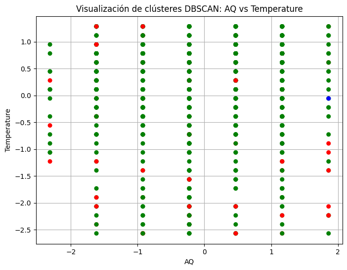

```python
# Creamos un nuevo DataFrame con los nombres originales
sensors_df_dbscan = pd.DataFrame(sensors_df_fit, columns=sensors_df.columns)
sensors_df_dbscan['label'] = labels

# Creamos un mapa de colores personalizado: rojo para -1, verde para 0, azul para 1
colores = {
    -1: 'red',    # ruido
     0: 'green',  # clúster principal
     1: 'blue'    # posible clúster secundario
}

# Aplicamos el color correspondiente a cada etiqueta
colores_asignados = sensors_df_dbscan['label'].map(colores)

# Graficamos el scatter con los colores definidos
plt.figure(figsize=(8, 6))
plt.scatter(
    sensors_df_dbscan['AQ'],
    sensors_df_dbscan['Temperature'],
    c=colores_asignados,
    s=30
)
plt.xlabel('AQ')
plt.ylabel('Temperature')
plt.title('Visualización de clústeres DBSCAN: AQ vs Temperature')
plt.grid(True)
plt.show()
```

El código comienza creando un nuevo *DataFrame* denominado `sensors_df_dbscan` que contiene los datos estandarizados con los nombres de las variables originales, a los que se les añade una nueva columna llamada `label` que almacena las etiquetas generadas por el algoritmo DBSCAN. Estas etiquetas indican el clúster al que pertenece cada observación, siendo `-1` para los puntos considerados como ruido y valores enteros no negativos para los distintos grupos identificados.

A continuación, se define un diccionario llamado `colores` que asigna manualmente un color específico a cada etiqueta: rojo para los puntos clasificados como ruido (`-1`), verde para los pertenecientes al clúster principal (`0`) y azul para aquellos asignados al clúster secundario (`1`). Luego se genera una nueva serie llamada `colores_asignados` aplicando este mapeo a la columna `label`, lo que permite asociar a cada punto su color correspondiente.

Con esta preparación, se representa un diagrama de dispersión mediante `plt.scatter()`, utilizando las variables `AQ` y `Temperature` como ejes X e Y respectivamente. Cada punto se colorea según la etiqueta de clúster que le ha asignado DBSCAN. Se añaden etiquetas a los ejes, un título y una cuadrícula para mejorar la legibilidad del gráfico.

La imagen resultante muestra cómo se distribuyen las observaciones en el plano `AQ`–`Temperature` tras la agrupación con DBSCAN. Visualmente, puede apreciarse que la mayoría de los puntos han sido asignados al clúster 0 (color verde), con una cantidad moderada de puntos clasificados como ruido (color rojo) y una presencia residual del clúster 1 (color azul), que apenas aparece en esta proyección. Esto confirma que en este plano concreto no existe una separación evidente entre múltiples agrupaciones, lo que refuerza la utilidad de DBSCAN para detectar estructuras densas en todo el espacio de características, más allá de lo que puede observarse en dos dimensiones aisladas.

Aunque la visualización en dos variables específicas puede aportar una primera aproximación a la estructura de los clústeres, en contextos multivariables como el actual resulta limitada para interpretar la distribución real de los datos. Para superar esta restricción, se proyectan los datos en un plano bidimensional mediante PCA, obteniendo una representación que conserva la mayor varianza posible del conjunto original. Esta transformación permite observar de forma más global y expresiva los agrupamientos formados por DBSCAN, sin depender de una selección arbitraria de variables.

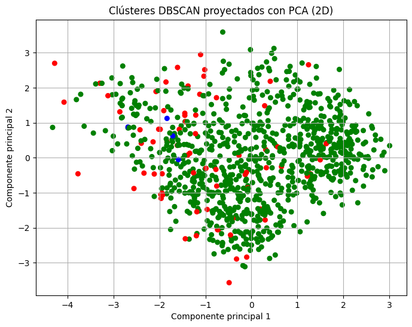

```python
# Aplicamos PCA para reducir los datos estandarizados a 2 dimensiones
pca = PCA(n_components=2)
pca_components = pca.fit_transform(sensors_df_fit)

# Creamos un DataFrame con los componentes y las etiquetas
df_pca = pd.DataFrame(pca_components, columns=['PC1', 'PC2'])
df_pca['label'] = labels

# Asignamos colores personalizados según el clúster: rojo para -1, verde para 0, azul para 1
colores = {
    -1: 'red',
     0: 'green',
     1: 'blue'
}
colores_asignados = df_pca['label'].map(colores)

# Visualizamos los clústeres proyectados en el espacio PCA
plt.figure(figsize=(8, 6))
plt.scatter(
    df_pca['PC1'],
    df_pca['PC2'],
    c=colores_asignados,
    s=30
)
plt.xlabel('Componente principal 1')
plt.ylabel('Componente principal 2')
plt.title('Clústeres DBSCAN proyectados con PCA (2D)')
plt.grid(True)
plt.show()
```

El código comienza aplicando una reducción de dimensionalidad mediante el algoritmo PCA con dos componentes, utilizando el método `.fit_transform()` sobre los datos estandarizados `sensors_df_fit`. Esta transformación genera dos nuevas variables, denominadas `PC1` y `PC2`, que representan las direcciones que concentran la mayor parte de la varianza del conjunto de datos original. Estas componentes permiten proyectar toda la información multivariable en un espacio bidimensional conservando su estructura más significativa.

A continuación, se construye un *DataFrame* llamado `df_pca` que contiene las dos componentes principales y las etiquetas de agrupamiento generadas por DBSCAN. Estas etiquetas (`label`) indican a qué clúster pertenece cada punto: `0` para el grupo principal, `1` para un grupo minoritario y `-1` para los puntos clasificados como ruido.

Para facilitar la visualización, se define un diccionario de colores personalizado que asigna el color rojo a los puntos de ruido (`-1`), verde al clúster principal (`0`) y azul al clúster secundario (`1`). Luego se aplica este mapeo a la columna `label` para obtener el color correspondiente a cada observación.

Finalmente, se genera un gráfico de dispersión en el que se representan los datos proyectados en el espacio de las dos primeras componentes principales. Cada punto aparece coloreado según su etiqueta de clúster, lo que permite observar visualmente la distribución y separación de los grupos detectados por DBSCAN.

El gráfico resultante muestra una nube de puntos mayoritariamente agrupados en el clúster 0 (verde), con una clara concentración en el centro del espacio PCA. Se observan también numerosos puntos dispersos en rojo, correspondientes a observaciones clasificadas como ruido. El clúster 1, representado en azul, aparece como un pequeño subconjunto localizado en una zona densa, pero minoritaria en términos de volumen. Esta visualización permite confirmar que DBSCAN ha detectado una gran agrupación central con comportamiento homogéneo, diferenciada de un conjunto de casos atípicos que no presentan densidad suficiente como para integrarse en un clúster definido.

Para mejorar la interpretación de los resultados obtenidos, se visualizarán a continuación los registros agrupados por clúster, lo que permitirá observar la proporción de observaciones en cada grupo, incluyendo aquellos identificados como ruido. Posteriormente, se creará un nuevo *dataset* que contendrá únicamente los registros considerados *outliers*, es decir, aquellas observaciones que DBSCAN no ha asignado a ningún clúster debido a su baja densidad local. Esta separación facilitará su análisis específico en fases posteriores.

```python
# Contamos cuántas observaciones hay en cada grupo según las etiquetas asignadas por DBSCAN
sensors_df_dbscan['label'].value_counts()
```

| label | count |
| --- | --- |
| 0 | 869 |
| -1 | 71 |
| 1 | 4 |

**dtype:** int64

El código utiliza el método `.value_counts()` sobre la columna `label` del *DataFrame* `sensors_df_dbscan`, que contiene las etiquetas generadas por el algoritmo DBSCAN. Cada valor representa un grupo distinto: los enteros no negativos (`0`, `1`, etc.) corresponden a los distintos clústeres detectados, mientras que el valor `-1` identifica las observaciones clasificadas como ruido u *outliers*. Al aplicar esta función, se obtiene una serie ordenada que muestra cuántas instancias pertenecen a cada categoría.

Los resultados indican que:

- **869 observaciones han sido clasificadas con la etiqueta `0`**, lo que significa que DBSCAN ha identificado un clúster principal muy denso que agrupa la gran mayoría de los registros. Este grupo representa el comportamiento más frecuente y homogéneo entre las máquinas analizadas.
- **71 observaciones han sido etiquetadas como `-1`**. Estas instancias no presentan suficiente densidad local para formar parte de ningún clúster y, por tanto, podrían reflejar comportamientos atípicos o anómalos, posiblemente relacionados con situaciones de fallo, condiciones extremas o registros poco comunes.
- **Solo 4 observaciones han sido asignadas al clúster `1`**, lo que sugiere la existencia de un grupo minoritario que cumple los criterios de densidad, pero que representa un segmento muy reducido dentro del conjunto. Aunque es un grupo válido, su tamaño tan pequeño indica que su estructura es débil o localizada en una región muy específica del espacio de características.

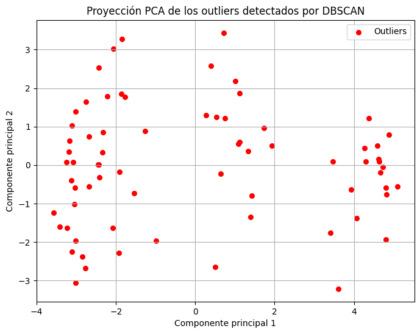

```python
# Filtramos las observaciones clasificadas como outliers por DBSCAN (label == -1)
outliers_df = sensors_df_dbscan[sensors_df_dbscan['label'] == -1]

# Seleccionamos solo las columnas numéricas originales, sin la etiqueta
outliers_data = outliers_df.drop(columns=['label'])

# Aplicamos PCA a los datos de los outliers
pca = PCA(n_components=2)
pca_outliers = pca.fit_transform(outliers_data)

# Creamos el DataFrame proyectado
df_outliers_pca = pd.DataFrame(pca_outliers, columns=['PC1', 'PC2'])

# Visualizamos
plt.figure(figsize=(8, 6))
plt.scatter(
    df_outliers_pca['PC1'],
    df_outliers_pca['PC2'],
    c='red',
    s=30,
    label='Outliers'
)
plt.xlabel('Componente principal 1')
plt.ylabel('Componente principal 2')
plt.title('Proyección PCA de los outliers detectados por DBSCAN')
plt.grid(True)
plt.legend()
plt.show()
```

Este código comienza aplicando el algoritmo PCA a los registros previamente identificados como *outliers* por DBSCAN. Para ello, se elimina la columna `label`, ya que no forma parte de las variables numéricas que deben intervenir en la reducción de dimensionalidad. Una vez preparados los datos, se crea una instancia de PCA con dos componentes principales y se ajusta el modelo utilizando `.fit_transform()`, lo que genera una representación bidimensional del conjunto de datos atípicos, manteniendo la mayor varianza posible.

A continuación, se construye un nuevo *DataFrame* que contiene las dos componentes principales (`PC1` y `PC2`) resultantes de la proyección. Esta estructura permite representar gráficamente los *outliers* en un plano bidimensional, facilitando su análisis visual. Finalmente, se genera un gráfico de dispersión en el que cada punto corresponde a una observación clasificada como *outlier*, representado en color rojo. Se añaden etiquetas a los ejes, un título descriptivo, cuadrícula y leyenda para facilitar la lectura del gráfico.

En cuanto a los resultados, la visualización muestra que las observaciones marcadas como *outliers* por DBSCAN no forman un único grupo compacto, sino que aparecen dispersas a lo largo de todo el espacio proyectado. Se observan algunas zonas donde los puntos están más concentrados, lo que podría indicar la presencia de subgrupos de comportamiento anómalo, aunque no suficientemente densos como para constituir un clúster según los criterios de DBSCAN. Esta dispersión sugiere que los registros clasificados como ruido presentan patrones diversos y alejados del comportamiento común, lo que justifica su exclusión de los clústeres principales.

```python
# Seleccionamos solo las columnas numéricas, excluyendo 'label'
outliers_only = outliers_df.drop(columns=['label'])

# Calculamos la media por variable
outliers_mean = outliers_only.mean().reset_index()

# Asignamos el nombre a las columnas
outliers_mean.columns = ['variable', 'value']

# Generamos el gráfico polar
fig = px.line_polar(outliers_mean,
                    r='value',
                    theta='variable',
                    line_close=True,
                    color_discrete_sequence=['red'],
                    height=800, width=800)
fig.show()
```

[figure not shown]

Se comienza seleccionando únicamente las columnas numéricas del *DataFrame* `outliers_df`, eliminando la columna `label`, ya que esta contiene únicamente la marca de clasificación como *outlier* y no aporta información útil para el perfil de variables. A continuación, se calcula la media de cada variable en ese subconjunto de datos, con el objetivo de obtener un perfil agregado que represente el comportamiento medio de las observaciones clasificadas como anómalas por DBSCAN. Esta media se transforma en un nuevo *DataFrame* en formato largo, donde cada fila contiene el nombre de una variable y su valor medio correspondiente.

Una vez estructurados los datos, se utiliza la función `px.line_polar()` de la librería Plotly para generar un gráfico polar en el que se representa la media estandarizada de cada variable. Se emplea un trazo de color rojo, coherente con la codificación visual previa para los *outliers*, y se establece un diseño circular cerrado (`line_close=True`). Este tipo de visualización permite observar de forma conjunta el perfil promedio de todas las variables, facilitando la identificación de desviaciones y patrones distintivos con respecto al conjunto general.

El gráfico polar evidencia que los *outliers* detectados por DBSCAN no son aleatorios, sino que presentan un perfil funcional específico, dominado por valores elevados de `footfall` y registros reducidos en varias variables técnicas. Esta combinación sugiere que las anomalías están relacionadas con condiciones de uso más intensivo y parámetros de funcionamiento menos comunes.

### 3.4 - Interpretación operativa y perfilado funcional de los clústeres

A lo largo del análisis realizado con DBSCAN, se ha observado que la mayoría de las observaciones fueron agrupadas en un clúster principal (`label = 0`), que representa un comportamiento operativo habitual, denso y homogéneo. Un segundo grupo minoritario (`label = 1`) aglutina tan solo unos pocos registros con características similares entre sí, pero insuficientemente frecuentes como para influir significativamente en la estructura global del conjunto. Finalmente, un conjunto de registros fue etiquetado como `-1`, es decir, *outliers*, representando aproximadamente un 7,5% del total.

La visualización de estos *outliers* en el espacio PCA permitió confirmar que no forman un grupo estructurado, sino que se encuentran dispersos por todo el espacio de representación, lo que respalda su clasificación como observaciones atípicas. Sin embargo, al analizar su perfil medio mediante un gráfico polar, se reveló que estos registros se asocian a un valor anómalamente alto en la variable `footfall` (2.18), lo que sugiere escenarios de alta afluencia o tránsito cerca de la máquina.

A nivel técnico, destacan valores notablemente reducidos en variables como `CS` (-0.70), `Temperature` (-0.66), `IP` (-0.41) y `VOC` (-0.35), lo que apunta a un funcionamiento en condiciones internas menos intensas o en estados fuera del régimen habitual. Por el contrario, variables como `USS` (0.33), `tempMode` (0.06), `RP` (0.03) o `AQ` (-0.06) muestran desviaciones leves o casi neutras. Esto sugiere que los registros anómalos responden a un perfil operativo concreto: alta interacción externa y parámetros internos que se alejan del comportamiento medio.

## 4. Dendrograma

### 4.1 - Aplica el algoritmo de AgglomerativeClustering a los datos

Antes de aplicar el algoritmo de agrupamiento jerárquico aglomerativo, conviene comprender cómo se configura su comportamiento mediante los hiperparámetros disponibles en su implementación en *scikit-learn*. A diferencia de los otros modelos vistos anteriormente, este enfoque no se basa en densidad ni en vecindad, sino en una estructura jerárquica de fusiones sucesivas entre muestras o grupos, que va construyendo clústeres de forma progresiva desde las unidades individuales hasta un único grupo global.

El comportamiento del modelo puede ajustarse mediante varios hiperparámetros, algunos de los cuales afectan directamente a la estructura del agrupamiento y otros influyen en la eficiencia del cálculo o en el tratamiento de los datos de entrada. A continuación se detallan los principales parámetros que ofrece la clase `AgglomerativeClustering` en *scikit-learn*:

#### `n_clusters`

Este parámetro indica el número de clústeres que se desea obtener como resultado final del proceso. Si se establece, el algoritmo continuará fusionando grupos hasta que queden exactamente `n_clusters`. Es el criterio más habitual para detener la jerarquía. Alternativamente, puede omitirse si se utiliza `distance_threshold`.

#### `metric`

Define la métrica de distancia utilizada para calcular la proximidad entre puntos individuales. Las opciones incluyen distancias estándar como `'euclidean'`, `'manhattan'`, `'cosine'`, entre otras. Por defecto, se emplea `'euclidean'`. Este parámetro solo tiene efecto cuando `linkage='average'` o `'complete'`.

#### `linkage`

Determina cómo se calcula la distancia entre grupos al realizar las fusiones. Las opciones disponibles son:

- `'ward'`: minimiza la varianza dentro de los clústeres, solo válida con la métrica `'euclidean'`.
- `'complete'`: utiliza la distancia máxima entre los puntos de dos grupos.
- `'average'`: emplea la distancia media entre todos los pares de puntos de ambos grupos.
- `'single'`: utiliza la distancia mínima entre dos puntos, uno de cada grupo.

El tipo de *linkage* elegido influye significativamente en la forma final de los clústeres.

#### `distance_threshold`

Permite definir una distancia máxima para las fusiones. Si se especifica, el modelo creará tantos clústeres como sean necesarios hasta que ninguna fusión supere ese umbral. En ese caso, no debe establecerse `n_clusters`.

#### `compute_full_tree`

Controla si se construye el árbol jerárquico completo incluso cuando no es necesario. Si se fija a `True`, el árbol completo se calcula aunque se haya definido `n_clusters`. Si se establece en `'auto'`, el árbol se construye solo si es útil para el resultado.

#### `compute_distances`

Si se activa (`True`), el modelo almacenará las distancias entre los clústeres fusionados en cada paso. Esto permite, por ejemplo, reconstruir un dendrograma o analizar la progresión de las fusiones.

#### `connectivity` y `affinity`

Estos parámetros, aunque disponibles, se utilizan en contextos más avanzados. `connectivity` permite imponer restricciones de vecindad sobre las posibles fusiones, y `affinity` (obsoleto en versiones recientes) definía la función de similitud entre muestras, reemplazada por `metric`.

Una vez revisados los principales hiperparámetros del algoritmo de agrupamiento jerárquico aglomerativo, se concluye que en contextos como el actual, donde ya se dispone de una referencia sobre la estructura de los datos, resulta adecuado fijar directamente el número de clústeres esperado mediante el parámetro `n_clusters`. En este caso se ha optado por **establecer tres clústeres**, en línea con los resultados previos obtenidos con K-Means y coherente con la estructura observada en los análisis exploratorios anteriores.

Dado que se pretende mantener cierta homogeneidad con los agrupamientos obtenidos en métodos anteriores, también se ha elegido la **métrica euclídea** como referencia para el cálculo de distancias entre muestras. Esto permite asegurar la comparabilidad entre modelos y mantener una interpretación geométrica sencilla del espacio de representación.

En cuanto al criterio de fusión (`linkage`), se ha seleccionado la opción `'ward'`, ya que esta minimiza la varianza interna de los grupos en cada paso del proceso jerárquico. Esta configuración favorece la formación de clústeres compactos y esféricos, similares en estructura a los generados por K-Means, lo que refuerza la consistencia entre métodos y facilita el análisis conjunto de los resultados. Esta decisión, además, contribuye a una segmentación más equilibrada del conjunto de datos, adecuada para detectar agrupamientos homogéneos en un espacio multivariable estandarizado.

```python
# Creamos el modelo AgglomerativeClustering
agnes_model = AgglomerativeClustering(n_clusters=3, metric='euclidean', linkage='ward')

# Ajustamos el modelo a los datos estandarizados y obtenemos las etiquetas de agrupamiento
labels = agnes_model.fit_predict(sensors_df_fit)
```

Se comienza creando una instancia del modelo `AgglomerativeClustering`, configurado para generar tres clústeres (`n_clusters=3`). Se selecciona la métrica `'euclidean'` para calcular las distancias entre observaciones, lo que permite mantener la coherencia con los métodos empleados en etapas anteriores del análisis. Además, se establece el criterio de fusión `'ward'`, que agrupa observaciones minimizando la varianza intra-clúster en cada paso jerárquico, favoreciendo la formación de grupos compactos y homogéneos.

Una vez definido el modelo, se aplica sobre el conjunto de datos estandarizados mediante el método `.fit_predict()`, que realiza el ajuste y devuelve directamente las etiquetas asignadas a cada observación. Estas etiquetas se almacenan en la variable `labels` y permitirán, en pasos posteriores, analizar la distribución de los clústeres y visualizar su estructura.

```python
# Creamos un nuevo DataFrame con los datos estandarizados y las etiquetas del modelo AGNES
agnes_df = pd.DataFrame(sensors_df_fit, columns=sensors_df.columns)
agnes_df['label'] = labels

# Contamos la distribución de observaciones por clúster
display(agnes_df['label'].value_counts())

# Calculamos el valor medio del coeficiente de silueta
silueta = silhouette_score(sensors_df_fit, labels)
print(f'\nCoeficiente de silueta: {silueta:.4f}')
```

| label | count |
| --- | --- |
| 0 | 411 |
| 1 | 401 |
| 2 | 132 |

**dtype:** int64

```
Coeficiente de silueta: 0.1673
```

Se crea un nuevo *DataFrame* denominado `agnes_df`, que contiene los datos estandarizados utilizados para el agrupamiento jerárquico, junto con una nueva columna `label` que almacena las etiquetas asignadas por el modelo AGNES. Esta estructura permite asociar cada observación con el clúster correspondiente, lo que facilita el análisis cuantitativo y visual posterior.

A continuación, se utiliza el método `.value_counts()` sobre la columna `label` para contar cuántas observaciones han sido clasificadas en cada grupo. Esto permite comprobar si la segmentación generada es equilibrada o si existen clústeres dominantes.

Finalmente, se calcula el **coeficiente de silueta global** con la función `silhouette_score()`, que evalúa el grado de cohesión y separación entre los clústeres. Este valor, que se almacena en la variable `silueta`, representa la media de todos los coeficientes de silueta individuales, proporcionando una medida sintética de la calidad geométrica del agrupamiento.

Los resultados muestran que los clústeres `0` y `1` agrupan un número similar de observaciones (411 y 401, respectivamente), mientras que el clúster `2` contiene 132 registros. Esta distribución sugiere una segmentación equilibrada, con la presencia de un grupo minoritario bien diferenciado.

El valor del coeficiente de silueta obtenido fue **0.1673**, lo que indica una calidad de agrupamiento moderadamente baja. Aunque existe cierta estructura reconocible, la cercanía entre los clústeres o la dispersión interna de sus elementos podría estar limitando la definición clara de los grupos. Esto sugiere que los clústeres podrían compartir zonas de solapamiento o estar afectados por ciertas variables que dificultan su separación neta. Para obtener una evaluación más completa, se representan gráficamente los resultados.

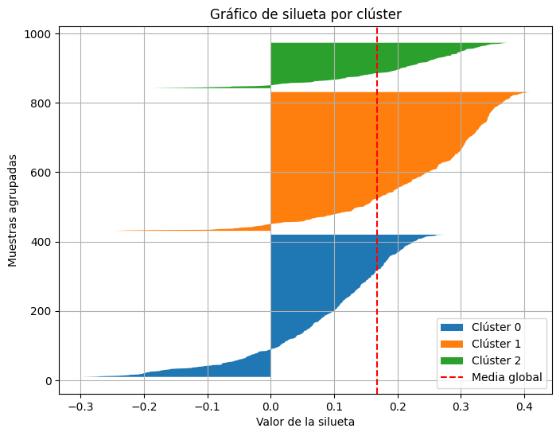

```python
# Obtenemos los valores individuales de silueta por muestra
silhouette_vals = silhouette_samples(sensors_df_fit, labels)

# Preparamos la visualización
plt.figure(figsize=(8, 6))
y_lower = 10
for i in np.unique(labels):
    ith_silhouette_vals = silhouette_vals[labels == i]
    ith_silhouette_vals.sort()
    size_cluster_i = ith_silhouette_vals.shape[0]
    y_upper = y_lower + size_cluster_i
    plt.fill_betweenx(np.arange(y_lower, y_upper),
                      0, ith_silhouette_vals, label=f'Clúster {i}')
    y_lower = y_upper + 10

plt.xlabel("Valor de la silueta")
plt.ylabel("Muestras agrupadas")
plt.title("Gráfico de silueta por clúster")
plt.axvline(x=silueta, color="red", linestyle="--", label="Media global")
plt.legend()
plt.grid(True)
plt.show()
```

El código comienza calculando el coeficiente de silueta individual para cada observación utilizando la función `silhouette_samples()`. Esta métrica evalúa, para cada punto, qué tan bien está agrupado con respecto a su propio clúster y qué tan lejos está de los demás. El resultado se almacena en la variable `silhouette_vals`, que contiene un valor por cada muestra del conjunto de datos.

A continuación, se construye un gráfico de silueta que representa la distribución de estos valores dentro de cada clúster. Para ello, se recorre cada etiqueta única en el modelo (`labels`) y se extraen los valores de silueta correspondientes a las observaciones de ese clúster. Estos valores se ordenan y se dibujan como bloques horizontales apilados verticalmente mediante `fill_betweenx()`. Se ajustan las posiciones de cada bloque utilizando las variables `y_lower` y `y_upper` para evitar solapamientos y mantener la separación visual entre grupos.

Finalmente, se añade una línea vertical roja mediante `axvline()` para indicar el valor medio global del coeficiente de silueta previamente calculado (`silueta`), y se configura el gráfico con etiquetas, leyenda y cuadrícula para facilitar su interpretación.

El gráfico permite visualizar la calidad del agrupamiento obtenido para cada uno de los tres clústeres generados por el modelo AGNES. Se observa que el **clúster 1** (en naranja) presenta una silueta más consistente y valores claramente positivos para la mayoría de sus observaciones, lo que indica una buena cohesión interna y una separación adecuada con respecto a los demás clústeres. Este comportamiento sugiere que el grupo está bien definido y representa una estructura coherente en el espacio de datos.

En cambio, el **clúster 0** (azul) muestra una mayor dispersión en los valores de silueta, incluyendo un número significativo de observaciones con valores negativos o cercanos a cero. Esto indica que muchas de sus muestras se encuentran en regiones de solapamiento con otros clústeres o tienen una asignación dudosa. El **clúster 2** (verde), aunque más reducido en tamaño, presenta una silueta intermedia, con valores mayoritariamente positivos, aunque también con cierta variabilidad.

La línea discontinua roja que marca la **media global del coeficiente de silueta** (≈ 0.167) e indica que el modelo logra una segmentación con cierta estructura, pero no completamente nítida. La presencia de valores negativos en algunos puntos sugiere que, aunque el agrupamiento jerárquico ha capturado ciertos patrones, existen zonas de ambigüedad.

Este análisis inicial ha permitido explorar la calidad del agrupamiento resultante al fijar previamente el número de clústeres en tres, lo que ofrece una primera aproximación a la estructura interna de los datos. Sin embargo, lo más adecuado en un algoritmo jerárquico como AgglomerativeClustering es **no asumir de antemano cuántos grupos existen**, sino **analizar cómo evolucionan las fusiones entre clústeres** a lo largo del proceso. Por ello, en el siguiente apartado se abordará la estimación del número óptimo de clústeres mediante un enfoque visual basado en el dendrograma. Esta representación permitirá observar las distancias a las que se realizan las fusiones y determinar, de forma justificada, en qué punto conviene interrumpir el proceso jerárquico para obtener una partición coherente y bien separada.

### 4.2 - Realiza un análisis de cuál es el número ideal de clústeres

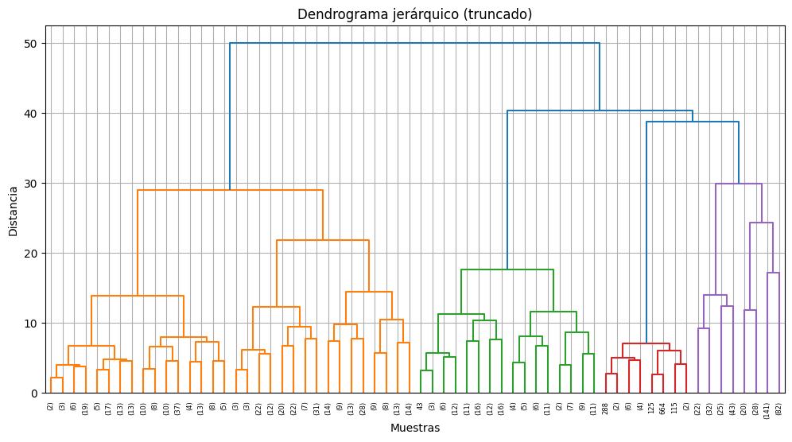

```python
# Calculamos la matriz de enlaces con el método 'ward'
Z = linkage(sensors_df_fit, method='ward')  # También podrías usar: 'single', 'complete', 'average'

# Dibujamos el dendrograma
plt.figure(figsize=(12, 6))
dendrogram(
    Z,
    truncate_mode='level',  # Limita la profundidad visual del árbol
    p=5,                    # Número de niveles a mostrar
    color_threshold=None    # Podemos establecerlo luego según el corte
)
plt.title("Dendrograma jerárquico (truncado)")
plt.xlabel("Muestras")
plt.ylabel("Distancia")
plt.grid(True)
plt.show()
```

El código comienza calculando la **matriz de enlaces (`Z`)** mediante la función `linkage()` de la librería `scipy.cluster.hierarchy`. Esta matriz representa el historial de fusiones realizadas durante el proceso jerárquico de agrupamiento. Se ha utilizado el método `'ward'`, que fusiona los grupos minimizando la varianza intra-clúster en cada paso. Esta elección es coherente con el enfoque empleado en el modelo AGNES previo y con los principios de K-Means, favoreciendo la creación de clústeres compactos y homogéneos.

Una vez generada la matriz, se construye el dendrograma mediante la función `dendrogram()`. En este caso, se ha especificado el parámetro `truncate_mode='level'`, que limita la visualización a los niveles superiores del árbol jerárquico, y se ha definido `p=5` para mostrar solo los cinco niveles más altos de fusión. Esta configuración permite obtener una representación simplificada y legible, especialmente útil cuando el número de observaciones es elevado. El gráfico resultante muestra las fusiones entre clústeres en función de la distancia entre ellos, con una escala vertical que representa esa distancia acumulada.

El dendrograma generado ofrece una visión de la estructura jerárquica del conjunto de datos. En él, cada línea horizontal representa una fusión entre dos clústeres, y la altura a la que se produce indica la distancia (en términos de varianza) entre los grupos fusionados. Se observa que las fusiones más recientes (ubicadas en la parte superior del gráfico) implican saltos más grandes de distancia, lo que sugiere que los grupos que se unieron en esas etapas eran más heterogéneos entre sí.

```python
# Creamos un DataFrame a partir de la matriz de enlaces
linkage_df = pd.DataFrame(Z, columns=['Grupo 1', 'Grupo 2', 'Distancia', 'Observaciones'])

# Mostramos las últimas fusiones ordenadas por distancia descendente
linkage_df_sorted = linkage_df.sort_values(by='Distancia', ascending=False).reset_index(drop=True)

# Mostramos las fusiones con mayor distancia (más significativas)
linkage_df_sorted.head(10)
```

|  | Grupo 1 | Grupo 2 | Distancia | Observaciones |
| --- | --- | --- | --- | --- |
| 0 | 1882.0 | 1885.0 | 49.909536 | 944.0 |
| 1 | 1879.0 | 1884.0 | 40.343998 | 543.0 |
| 2 | 1846.0 | 1883.0 | 38.714976 | 411.0 |
| 3 | 1876.0 | 1881.0 | 29.887230 | 393.0 |
| 4 | 1875.0 | 1880.0 | 28.926537 | 401.0 |
| 5 | 1871.0 | 1878.0 | 24.327630 | 271.0 |
| 6 | 1872.0 | 1877.0 | 21.884339 | 228.0 |
| 7 | 1868.0 | 1869.0 | 17.626838 | 132.0 |
| 8 | 1870.0 | 1874.0 | 17.167537 | 223.0 |
| 9 | 1864.0 | 1867.0 | 14.463909 | 108.0 |

El código comienza construyendo un nuevo *DataFrame* llamado `linkage_df` a partir de la matriz de enlaces `Z`, generada previamente mediante la función `linkage()`. Esta matriz contiene el historial completo de fusiones realizadas durante el proceso jerárquico. Se le asignan cuatro columnas: `Grupo 1` y `Grupo 2`, que identifican los elementos o grupos que se fusionan en cada paso; `Distancia`, que indica a qué distancia (en términos de varianza) se produce esa fusión; y `Observaciones`, que representa el tamaño total del nuevo grupo formado.

A continuación, se ordenan las fusiones por la columna `Distancia` en orden descendente, con el objetivo de identificar aquellas combinaciones que se realizaron a mayor distancia. Estas fusiones son las más significativas, ya que indican momentos en los que se unieron grupos que estaban previamente más alejados o eran más disímiles entre sí. La tabla resultante, `linkage_df_sorted`, se resetea en el índice para facilitar su lectura.

Finalmente, se muestran las 10 fusiones con mayor distancia, lo que permite analizar cuantitativamente los saltos jerárquicos más relevantes del modelo. Esta tabla sirve como complemento al análisis visual del dendrograma, y proporciona una base numérica para determinar el punto de corte más adecuado en el árbol jerárquico.

El análisis de la matriz de enlaces jerárquicos muestra dos **saltos abruptos en las distancias de fusión**, que son claves para determinar el número óptimo de clústeres. Estos saltos indican momentos en los que se produce una unión significativa entre grupos que, hasta ese punto, presentaban una diferenciación estructural clara.

En particular, se detectan:

- Un **primer salto** entre una distancia de **≈29.88** y **≈40.34**, que representa una fusión de gran impacto en la jerarquía. Cortar el dendrograma justo antes de esta unión sugiere una partición en **tres clústeres**, conservando los principales bloques estructurales.
- Un **segundo salto** entre **≈28.92** y **≈38.71**, igualmente marcado. En este caso, el corte anterior a dicha fusión permite mantener una segmentación más detallada en **cuatro clústeres**, preservando la diversidad interna que aún existe en ese nivel de la jerarquía.

Ambas opciones están respaldadas por la diferencia de escala en las distancias de fusión y por lo observado en la representación visual del dendrograma. Sin embargo, para garantizar una elección justificada y no exclusivamente visual, se ha optado por **complementar el análisis con métricas cuantitativas**, como el coeficiente de silueta y el índice de Davies-Bouldin.

```python
from sklearn.metrics import davies_bouldin_score

# Rango de valores de k a evaluar
k_values = range(2, 7)

# Listas para almacenar los resultados
silhouette_scores = []
davies_bouldin_scores = []

# Entrenamos AGNES para cada valor de k y calculamos las métricas
for k in k_values:
    model = AgglomerativeClustering(n_clusters=k, linkage='ward')
    labels = model.fit_predict(sensors_df_fit)

    sil_score = silhouette_score(sensors_df_fit, labels)
    db_score = davies_bouldin_score(sensors_df_fit, labels)

    silhouette_scores.append(round(sil_score, 4))
    davies_bouldin_scores.append(round(db_score, 4))

# Creamos un DataFrame con los resultados
metrics_df = pd.DataFrame({
    'n_clusters': list(k_values),
    'Silhouette Score': silhouette_scores,
    'Davies-Bouldin Score': davies_bouldin_scores
})

# Mostramos la tabla de métricas
display(metrics_df)
```

|  | n_clusters | Silhouette Score | Davies-Bouldin Score |
| --- | --- | --- | --- |
| 0 | 2 | 0.1453 | 2.2026 |
| 1 | 3 | 0.1673 | 2.0134 |
| 2 | 4 | 0.1803 | 1.6333 |
| 3 | 5 | 0.1586 | 1.5844 |
| 4 | 6 | 0.1392 | 1.6329 |

El código evalúa diferentes configuraciones del algoritmo *Agglomerative Clustering* (AGNES), variando el número de clústeres entre 2 y 6, con el objetivo de determinar cuál de ellos ofrece la mejor calidad de agrupamiento en el conjunto de datos estandarizado `sensors_df_fit`.

Para cada valor de *k*, se instancia un modelo de clustering jerárquico utilizando el método de enlace `ward`, que agrupa observaciones minimizando la varianza interna de los grupos fusionados. Una vez ajustado el modelo con `.fit_predict()`, se obtienen las etiquetas asignadas a cada observación y se calculan dos métricas internas:

- El **coeficiente de silueta** (`silhouette_score`), que evalúa qué tan cerca están las observaciones dentro de un mismo clúster en comparación con los demás. Cuanto más alto es este valor (máximo 1), mayor es la cohesión y la separación entre clústeres.
- El **índice de Davies-Bouldin** (`davies_bouldin_score`), que mide la cohesión y separación entre los grupos formados. En este caso, valores más bajos indican una mejor estructura de agrupamiento.

Ambas métricas se almacenan y se presentan en un *DataFrame* para su comparación directa.

A la vista de los resultados, el valor de *k = 4* presenta el **coeficiente de silueta más alto** y uno de los **índices de Davies-Bouldin más bajos**, lo que sugiere una buena separación entre los grupos con una estructura interna coherente. Aunque *k = 5* tiene un valor de Davies-Bouldin ligeramente inferior, su puntuación de silueta disminuye de forma notable, lo que indica menor cohesión y separación.

### 4.3 - Aplica de nuevo el clustering jerárquico con el número de clústeres elegido y crea un dataframe con los datos y las etiquetas otorgadas por el algoritmo.

```python
# Creamos el modelo AgglomerativeClustering con 4 clústeres
agnes_model = AgglomerativeClustering(n_clusters=4, metric='euclidean', linkage='ward')

# Ajustamos el modelo y obtenemos las etiquetas
labels = agnes_model.fit_predict(sensors_df_fit)

# Creamos un nuevo DataFrame con los datos y las etiquetas
agnes_df = pd.DataFrame(sensors_df_fit, columns=sensors_df.columns)
agnes_df['label'] = labels

# Mostramos los 5 primeros registros del nuevo DataFrame
agnes_df.head()
```

|  | footfall | tempMode | AQ | USS | CS | VOC | RP | IP | Temperature | label |
| --- | --- | --- | --- | --- | --- | --- | --- | --- | --- | --- |
| 0 | -0.283153 | 1.222896 | 1.860497 | -1.402480 | 0.477610 | 1.389813 | -0.672788 | -0.979504 | -2.567407 | 1 |
| 1 | -0.107558 | -1.019410 | -0.921775 | 0.043660 | -0.310613 | -0.810763 | -1.647540 | -0.353894 | -2.567407 | 0 |
| 2 | -0.254504 | 1.222896 | -1.617343 | -0.679410 | 0.477610 | -0.810763 | -1.403852 | 0.897327 | -2.567407 | 0 |
| 3 | -0.206446 | 0.101743 | -0.921775 | 0.766730 | -0.310613 | -0.810763 | -1.160164 | 0.897327 | -2.567407 | 0 |
| 4 | 0.308326 | 1.222896 | 0.469361 | 2.212869 | -1.098836 | -1.250878 | 1.276716 | 0.897327 | -2.567407 | 2 |

En primer lugar, se instancia el modelo `agnes_model` especificando `n_clusters=4` y `linkage='ward'`, lo que indica que las fusiones entre observaciones se realizarán minimizando la varianza interna de los grupos. Aunque se incluye el parámetro `metric='euclidean'`, este no es necesario explícitamente al utilizar el método `ward`, ya que internamente este enlace opera únicamente sobre distancias euclídeas.

Una vez definido el modelo, se entrena y se obtienen las etiquetas de agrupamiento mediante `fit_predict()` sobre el conjunto de datos `sensors_df_fit`. Estas etiquetas representan el clúster asignado a cada observación.

A continuación, se construye un nuevo *DataFrame* denominado `agnes_df`, combinando los datos estandarizados con la columna `label` que contiene las etiquetas generadas por el modelo. Este nuevo *DataFrame* incorpora explícitamente la estructura de clústeres detectada, lo que permite trabajar directamente con los grupos formados en posteriores análisis o visualizaciones.

Finalmente, se visualizan las cinco primeras filas de `agnes_df` como comprobación preliminar del resultado.

## 5. Análisis

### 5.1 - Realiza un análisis detallado de cada uno de los grupos generados por los algoritmos aplicados anteriormente y decide cuál es el mejor método para el conjunto de datos.

> Utiliza gráficos o tablas para apoyar tus conclusiones

#### 5.1.1 - Introducción comparativa de los algoritmos de agrupamiento

Antes de analizar en detalle los resultados obtenidos por cada uno de los modelos aplicados, conviene contextualizar brevemente las características fundamentales de los algoritmos empleados y el tipo de agrupamiento que cada uno de ellos está diseñado para identificar. Esta distinción es relevante, ya que no todos los métodos responden al mismo enfoque ni buscan resolver el problema desde la misma perspectiva matemática.

- **K-Means** es un algoritmo particional que agrupa las observaciones minimizando la varianza intra-clúster. Cada grupo se representa mediante un centroide, y la asignación de las muestras se realiza en función de su cercanía a estos centros. Su uso es adecuado cuando se presupone una estructura esférica y homogénea de los grupos, aunque es sensible a la escala y a la presencia de *outliers*.
- **AgglomerativeClustering (AGNES)** es un algoritmo jerárquico que no parte de un número fijo de grupos, sino que construye una estructura de fusiones sucesivas entre observaciones, generando un árbol jerárquico que representa todas las posibles agrupaciones. Esto permite explorar distintos niveles de segmentación y analizar visualmente la coherencia estructural del conjunto. Requiere también estandarizar los datos, ya que las decisiones de fusión se basan en distancias métricas.
- **DBSCAN**, por su parte, identifica clústeres en función de la densidad local de puntos. No necesita que se indique el número de grupos previamente y tiene la capacidad de detectar automáticamente observaciones que no pertenecen a ningún clúster, clasificándolas como ruido. Esta característica lo convierte en una herramienta especialmente útil para la detección de anomalías. Sin embargo, su rendimiento puede verse afectado si los clústeres tienen densidades muy dispares.

Cada uno de estos algoritmos responde, por tanto, a una lógica distinta de agrupamiento, lo que hace posible obtener resultados complementarios según la estructura real de los datos. Este análisis comparativo permitirá valorar cuál de ellos se adapta mejor al conjunto de sensores analizado.

#### 5.1.2 – Análisis estructural de los agrupamientos

Se comparará la segmentación generada por los tres algoritmos aplicados: **K-Means**, **AgglomerativeClustering (AGNES)** y **DBSCAN**, desde una perspectiva cuantitativa. Para ello, se analizará la distribución de observaciones en cada clúster, la detección de outliers, y, cuando sea aplicable, el coeficiente de silueta que evalúa la calidad geométrica del agrupamiento.

```python
# Obtenemos los conteos de cada algoritmo
kmeans_counts = clusters_kmeans['label'].value_counts().rename('KMeans')
agnes_counts = agnes_df['label'].value_counts().rename('AGNES')
dbscan_counts = sensors_df_dbscan['label'].value_counts().rename('DBSCAN')

# Unimos todos los conteos en un solo DataFrame
comparacion_clusters = pd.concat([kmeans_counts, agnes_counts, dbscan_counts], axis=1)

# Mostramos la tabla combinada
display(comparacion_clusters.fillna(0).astype(int))
```

| label | KMeans | AGNES | DBSCAN |
| --- | --- | --- | --- |
| 1 | 384 | 401 | 4 |
| 0 | 345 | 393 | 869 |
| 2 | 215 | 132 | 0 |
| 3 | 0 | 18 | 0 |
| -1 | 0 | 0 | 71 |

El código comienza extrayendo el número de observaciones por clúster para cada uno de los tres algoritmos utilizados: *K-Means*, *AGNES* y *DBSCAN*. Para ello, se aplica el método `.value_counts()` sobre la columna `label` de cada *DataFrame*, que contiene las etiquetas de agrupamiento generadas por cada modelo. Posteriormente, se renombran estas series con el nombre del algoritmo correspondiente mediante `.rename()`, lo que facilita su identificación en la tabla final.

A continuación, se utiliza `pd.concat()` con `axis=1` para combinar las tres series en un único *DataFrame*, alineando los índices (es decir, los valores de las etiquetas) y disponiendo cada algoritmo como una columna independiente. Este paso permite visualizar de forma conjunta cuántas observaciones han sido asignadas a cada clúster por cada técnica de agrupamiento, facilitando la comparación directa entre modelos.

Finalmente, se muestra la tabla combinada aplicando `fillna(0)` para reemplazar posibles valores nulos por ceros —en caso de que algún algoritmo no haya generado un determinado clúster—, y `astype(int)` para convertir los valores a enteros. El resultado es una matriz clara y consolidada que resume la distribución de observaciones por clúster en cada uno de los métodos, lo que resulta especialmente útil para analizar la estructura general de los agrupamientos y evaluar la coherencia entre modelos.

Por su parte, **DBSCAN** se comporta de forma radicalmente distinta al basarse en la densidad local para construir los clústeres. En su resultado, se observa un grupo mayoritario con 869 registros (clúster 0), un grupo residual con solo 4 observaciones (clúster 1), y un total de 71 registros identificados como *outliers* (etiqueta -1). Esta capacidad para excluir puntos que no forman parte de ninguna agrupación densa convierte a DBSCAN en una herramienta especialmente útil para la detección de anomalías. En este caso, la estructura identificada revela una alta concentración de datos en una región dominante del espacio, y una zona periférica dispersa que el algoritmo no ha considerado suficientemente compacta como para generar nuevos clústeres válidos.

#### 5.1.3 – Análisis funcional de los agrupamientos

Una vez revisada la estructura de los clústeres generados por cada modelo, se procede a analizar en profundidad el perfil funcional de cada grupo, atendiendo al comportamiento medio de las variables que componen el conjunto de datos. Este análisis permite ir más allá de la segmentación numérica y explorar el sentido operativo de cada agrupamiento, es decir, qué representa funcionalmente cada clúster y cómo se diferencian entre sí en términos de condiciones de funcionamiento de la máquina. Para ello, se emplearán los gráficos polar generados previamente, así como las tablas de medias estandarizadas, que recogen la intensidad relativa de cada variable en los distintos clústeres.

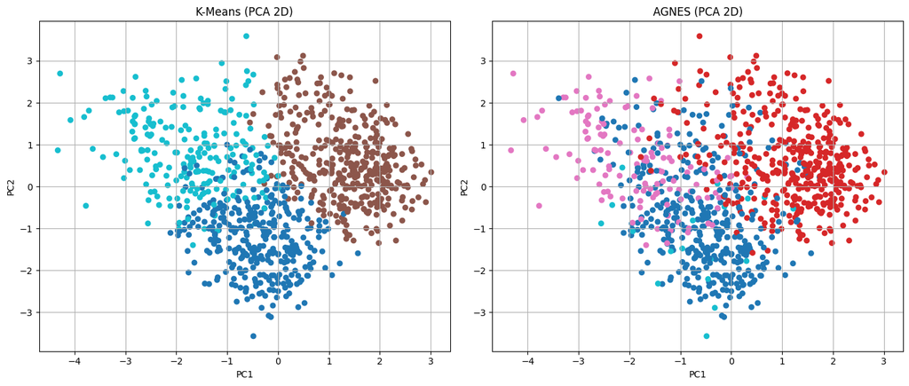

```python
# Aplicamos PCA una única vez sobre los datos estandarizados
pca = PCA(n_components=2)
pca_components = pca.fit_transform(sensors_df_fit)

# Creamos los DataFrames con los resultados de PCA y las etiquetas de cada modelo
pca_df_kmeans = pd.DataFrame(pca_components, columns=['PC1', 'PC2'])
pca_df_kmeans['label'] = clusters_kmeans['label']

pca_df_agnes = pd.DataFrame(pca_components, columns=['PC1', 'PC2'])
pca_df_agnes['label'] = agnes_df['label']

# Graficamos en dos subgráficos en paralelo
fig, axes = plt.subplots(1, 2, figsize=(14, 6))

# K-Means
axes[0].scatter(pca_df_kmeans['PC1'], pca_df_kmeans['PC2'],
                c=pca_df_kmeans['label'], cmap='tab10', s=30)
axes[0].set_title('K-Means (PCA 2D)')
axes[0].set_xlabel('PC1')
axes[0].set_ylabel('PC2')
axes[0].grid(True)

# AGNES
axes[1].scatter(pca_df_agnes['PC1'], pca_df_agnes['PC2'],
                c=pca_df_agnes['label'], cmap='tab10', s=30)
axes[1].set_title('AGNES (PCA 2D)')
axes[1].set_xlabel('PC1')
axes[1].set_ylabel('PC2')
axes[1].grid(True)

plt.tight_layout()
plt.show()
```

Esta representación permite comparar visualmente la forma en que los algoritmos *K-Means* y *AGNES* han segmentado el conjunto de datos tras aplicar una reducción de dimensionalidad mediante *PCA*. En el caso de *K-Means*, la partición mantiene su estructura previa de tres clústeres, mientras que *AGNES* ha generado una segmentación en cuatro grupos, como reflejo de la nueva configuración jerárquica adoptada.

En conjunto, la visualización pone de manifiesto la diferencia conceptual entre ambos enfoques: mientras *K-Means* ofrece una segmentación **más directa y operativa**, adecuada para tareas de clasificación estricta, *AGNES* aporta una **visión estructural más rica**.

```python
# Calculamos medias estandarizadas por clúster para AGNES
cluster_means_agnes = agnes_df.groupby("label").mean().reset_index()

# Formato largo para gráfico polar
polar_agnes = pd.melt(cluster_means_agnes, id_vars="label")

fig = go.Figure()

# K-Means
for label in polar_kmeans['label'].unique():
    cluster_data = polar_kmeans[polar_kmeans['label'] == label]
    fig.add_trace(go.Scatterpolar(
        r=cluster_data['value'],
        theta=cluster_data['variable'],
        name=f'Clúster {label} (K-Means)',
        line=dict(shape='linear', dash='solid')
    ))

# AGNES
for label in polar_agnes['label'].unique():
    cluster_data = polar_agnes[polar_agnes['label'] == label]
    fig.add_trace(go.Scatterpolar(
        r=cluster_data['value'],
        theta=cluster_data['variable'],
        name=f'Clúster {label} (AGNES)',
        line=dict(shape='linear', dash='dot')
    ))

# DBSCAN - Outliers
fig.add_trace(go.Scatterpolar(
    r=outliers_mean['value'],
    theta=outliers_mean['variable'],
    name='Outliers (DBSCAN)',
    line=dict(color='red', dash='dash'),
    opacity=0.9
))

fig.update_layout(
    title='Comparación de perfiles medios por algoritmo',
    polar=dict(radialaxis=dict(visible=True)),
    showlegend=True,
    height=800,
    width=800
)

fig.show()
```

[figure not shown]

El gráfico polar superpuesto permite comparar de forma clara y precisa los perfiles medios generados por los algoritmos *K-Means* y *AGNES*, así como el comportamiento funcional característico de los *outliers* detectados por *DBSCAN*. Esta visualización facilita la identificación de patrones comunes, discrepancias y rasgos distintivos relevantes desde una perspectiva operativa.

Los clústeres obtenidos por *K-Means* (líneas continuas) y *AGNES* (líneas punteadas) presentan trayectorias generales similares en varias de las variables monitorizadas, especialmente en `RP`, `IP`, `VOC` y `CS`, lo que sugiere que ambos algoritmos han captado una estructura subyacente común en el conjunto de datos. Sin embargo, se identifican diferencias significativas en la forma y dispersión de los perfiles. *AGNES* incorpora un cuarto grupo que introduce una nueva dinámica en el análisis: este clúster adicional se aleja de los patrones dominantes, capturando una variación intermedia no reflejada por los perfiles de *K-Means*. Resulta especialmente relevante la similitud del perfil medio de este clúster 3 con el trazado correspondiente a los registros atípicos identificados por *DBSCAN*, ya que ambos comparten una estructura anómala caracterizada por valores elevados en `footfall` y desviaciones en otras variables clave. Esta coincidencia sugiere que, aunque desde una lógica distinta, ambos algoritmos han logrado aislar un subconjunto de observaciones con un comportamiento funcional diferencial.

El trazado correspondiente a los *outliers* detectados por *DBSCAN*, representado mediante una línea discontinua en color rojo, muestra un perfil netamente diferenciado: destaca un valor muy elevado en la variable `footfall`, acompañado de niveles más bajos en `Temperature`, `CS` e `IP`. Este comportamiento sugiere que los registros etiquetados como atípicos están asociados a situaciones de alta actividad externa, posiblemente vinculadas al tránsito o presencia en el entorno, combinadas con condiciones internas más inusuales o distorsionadas. El hecho de que este patrón no se alinee con ninguno de los clústeres generados por *K-Means* refuerza su carácter anómalo y confirma su exclusión justificada como parte de un análisis más fino de calidad de datos.

En conjunto, esta representación aporta una interpretación operativa rica y complementaria:

- *K-Means* facilita una segmentación directa y operativa basada en perfiles bien definidos, útil para tareas de clasificación rápida.
- *AGNES* ofrece una agrupación más matizada, que preserva relaciones jerárquicas y revela perfiles intermedios no capturados por métodos particionales.
- *DBSCAN* actúa como herramienta clave para la detección de anomalías estructurales, identificando registros que escapan a los patrones dominantes y que podrían corresponder a eventos singulares o condiciones fuera de norma.

#### 5.1.4 – Evaluación del impacto de los *outliers* sobre la agrupación de K-Means

Una vez analizados los resultados obtenidos con los distintos algoritmos de agrupamiento, cabe plantear si la presencia de observaciones anómalas afecta negativamente a la calidad de la segmentación generada por K-Means. Dado que este algoritmo es especialmente sensible a los valores extremos, y que DBSCAN ha permitido identificar un subconjunto de registros considerados *outliers*, resulta pertinente explorar cómo se comporta K-Means cuando estos registros son excluidos del análisis.

Para ello, se procede a **entrenar de nuevo el modelo K-Means sobre un conjunto depurado**, en el que se han eliminado las observaciones etiquetadas como ruido (`label = -1`) por DBSCAN. Esto permitirá valorar si el agrupamiento resultante mejora en términos de cohesión, equilibrio y diferenciación entre clústeres, lo que aportará una visión más precisa sobre el efecto distorsionador de los *outliers* en este tipo de segmentación basada en centroides.

```python
# Eliminamos los outliers (label = -1) del DataFrame estandarizado original
sensors_df_clean = sensors_df_dbscan[sensors_df_dbscan['label'] != -1].drop(columns=['label'])

# Reentrenamos K-Means con los datos limpios
kmeans_clean = KMeans(n_clusters=3, init='k-means++', random_state=42)
labels_clean = kmeans_clean.fit_predict(sensors_df_clean)

# Creamos DataFrame con etiquetas y analizar la distribución
kmeans_clean_df = sensors_df_clean.copy()
kmeans_clean_df['label'] = labels_clean

# Calculamos el coeficiente de silueta
silhouette_clean = silhouette_score(sensors_df_clean, labels_clean)

# Mostrar resultados
display(kmeans_clean_df['label'].value_counts())
print(f"\nCoeficiente de silueta (sin outliers): {silhouette_clean:.4f}")
```

| label | count |
| --- | --- |
| 0 | 368 |
| 1 | 322 |
| 2 | 183 |

**dtype:** int64

```
Coeficiente de silueta (sin outliers): 0.2049
```

El código comienza eliminando del conjunto estandarizado original aquellas observaciones que fueron clasificadas como *outliers* por el algoritmo DBSCAN, es decir, aquellas con la etiqueta `label = -1`. Para ello, se parte del *DataFrame* `sensors_df_dbscan`, que ya contenía las etiquetas de DBSCAN, y se filtran los registros manteniendo únicamente los que pertenecen a clústeres válidos (`label` distinto de -1). Además, se elimina la columna de etiquetas previa para evitar conflictos en el nuevo entrenamiento.

A continuación, se reentrena el modelo *K-Means* sobre este nuevo conjunto depurado (`sensors_df_clean`). Se emplea el mismo número de clústeres que en el modelo original (`n_clusters = 3`), con inicialización *K-Means++* y semilla fija para asegurar la reproducibilidad de los resultados. Las etiquetas resultantes del nuevo modelo se almacenan y se integran en un nuevo *DataFrame*, sobre el cual se analiza la distribución de observaciones por clúster.

Finalmente, se calcula el coeficiente de silueta sobre el conjunto limpio.

Tras eliminar los *outliers* identificados por DBSCAN, el modelo K-Means mantiene una estructura de tres clústeres relativamente similar en cuanto a proporciones:

- Clúster 0: 368 observaciones
- Clúster 1: 322 observaciones
- Clúster 2: 183 observaciones

Aunque el coeficiente de silueta ha aumentado ligeramente tras la eliminación de los *outliers*, alcanzando un valor de **0.2049**, la mejora no resulta especialmente pronunciada. Esto sugiere que, si bien los registros anómalos introducían cierta distorsión en la segmentación, su impacto global sobre la calidad geométrica del agrupamiento no era determinante.

En cualquier caso, este resultado pone de manifiesto que **la exclusión de observaciones atípicas puede afinar la representación interna de los clústeres**, pudiendo permitir una mejor adaptación de los centroides al comportamiento dominante del conjunto.

```python
# Calculamos medias estandarizadas por clúster para K-Means con y sin outliers
kmeans_original_means = clusters_kmeans.groupby("label").mean().reset_index()
polar_kmeans_original = pd.melt(kmeans_original_means, id_vars="label")

kmeans_clean_means = kmeans_clean_df.groupby("label").mean().reset_index()
polar_kmeans_clean = pd.melt(kmeans_clean_means, id_vars="label")

# Creamos el gráfico polar
fig = go.Figure()

# K-Means original
for label in polar_kmeans_original['label'].unique():
    cluster_data = polar_kmeans_original[polar_kmeans_original['label'] == label]
    fig.add_trace(go.Scatterpolar(
        r=cluster_data['value'],
        theta=cluster_data['variable'],
        name=f'Clúster {label} (Original)',
        line=dict(shape='linear', dash='solid')
    ))

# K-Means sin outliers
for label in polar_kmeans_clean['label'].unique():
    cluster_data = polar_kmeans_clean[polar_kmeans_clean['label'] == label]
    fig.add_trace(go.Scatterpolar(
        r=cluster_data['value'],
        theta=cluster_data['variable'],
        name=f'Clúster {label} (Sin outliers)',
        line=dict(shape='linear', dash='dot')
    ))

# Ajustes de diseño
fig.update_layout(
    title='Comparación de perfiles medios: K-Means con y sin outliers',
    polar=dict(radialaxis=dict(visible=True)),
    showlegend=True,
    height=800,
    width=800
)

fig.show()
```

[figure not shown]

El gráfico polar presentado permite comparar los perfiles medios de los clústeres generados por *K-Means* antes y después de eliminar los *outliers* detectados mediante *DBSCAN*. Las líneas correspondientes a cada grupo muestran una **coincidencia elevada**, con trayectorias prácticamente paralelas a lo largo de todas las variables, lo que indica que **los centroides apenas han sufrido desplazamientos significativos**. Esta estabilidad sugiere que la estructura interna de los clústeres se ha mantenido firme, incluso tras suprimir los registros considerados anómalos.

Este resultado es coherente con la mejora moderada del coeficiente de silueta, que aumentó de 0.1909 a 0.2049, reflejando una ligera optimización en la cohesión interna de los grupos. Sin embargo, **no se aprecia un impacto sustancial en la segmentación funcional ni en la geometría relativa de los agrupamientos**.

La explicación más probable radica en la composición del conjunto de datos: de un total de 944 registros, solo 71 fueron clasificados como *outliers*, lo que supone una proporción reducida. En contextos con mayor dispersión o con un volumen de anomalías más significativo, **la exclusión de estos valores extremos podría tener un efecto más pronunciado** tanto en las métricas de validación como en los perfiles medios.

En este caso concreto, utilizar *DBSCAN* como filtro previo a *K-Means* **ha servido principalmente como mecanismo de verificación de la robustez del modelo**, más que como un transformador de la segmentación. No obstante, su utilidad se mantiene clara: identificar comportamientos operativos atípicos que podrían estar relacionados con condiciones inusuales de uso, sobrecarga o eventos puntuales. Por tanto, aunque su efecto sobre la estructura de los clústeres haya sido limitado, **su valor añadido en entornos industriales radica en su capacidad para detectar de forma anticipada posibles desviaciones que comprometan la estabilidad de las máquinas**.

#### 5.1.5 - Perfilado funcional de los clústeres y observaciones atípicas

El análisis de los perfiles medios, representado mediante gráficos polares, ha permitido caracterizar de forma detallada los clústeres generados por los algoritmos de *K-Means* y *Agglomerative Clustering* (AGNES), así como el grupo de observaciones clasificadas como *outliers* por *DBSCAN*. La consistencia general de los patrones entre algoritmos refuerza la validez estructural de la segmentación, al tiempo que las discrepancias puntuales revelan matices funcionales de interés.

El **clúster 0**, identificado en ambos modelos, presenta valores bajos en `AQ`, `CS` y `VOC`, indicadores relacionados con la calidad ambiental, junto con registros negativos en `RP` y `USS`, que reflejan escasa actividad mecánica o física. Este perfil sugiere un entorno de funcionamiento estable, con bajo estrés térmico y operacional, posiblemente vinculado a zonas de menor tránsito o equipos en estado de reposo sostenido. Puede interpretarse como un **grupo de baja carga ambiental y funcional**, favorable desde el punto de vista del desgaste y la necesidad de mantenimiento.

El **clúster 1** concentra registros con niveles elevados en `VOC`, `RP`, `CS` e `IP`, lo que denota una mayor exigencia operativa y un entorno más activo tanto en términos de presencia humana como de uso eléctrico. Este grupo podría corresponder a máquinas ubicadas en zonas de trabajo intensivo, expuestas a condiciones menos controladas y con una mayor probabilidad de sufrir desgaste por uso prolongado. Su perfil define un segmento de **alta carga funcional y ambiental**, que requiere atención específica desde el punto de vista de mantenimiento predictivo o preventivo.

El **clúster 2** muestra una configuración más heterogénea: destaca un aumento en `USS`, junto con valores más bajos en `CS`, `VOC` e `IP`. Esta combinación sugiere un comportamiento intermedio, posiblemente asociado a equipos en tránsito entre distintos estados funcionales o a zonas que alternan momentos de actividad y reposo. El perfil apunta a un **grupo funcionalmente versátil o híbrido**, difícil de clasificar con rigidez, pero relevante para tareas de supervisión continua.

El modelo jerárquico *AGNES* introduce un **cuarto clúster** adicional (clúster 3) que no tiene equivalente directo en *K-Means*, pero cuya trayectoria media guarda una notable similitud con el perfil de los registros atípicos detectados por *DBSCAN*. Ambos presentan un valor elevado en la variable `footfall` y mantienen registros reducidos en el resto de dimensiones. Esta semejanza sugiere que *AGNES*, sin excluir directamente estas observaciones, ha conseguido aislarlas en un grupo diferenciado, reconociendo su comportamiento atípico desde una lógica estructural. Este clúster puede interpretarse como un conjunto de máquinas o sensores en zonas de paso continuo, con baja actividad mecánica, posiblemente expuestos a eventos no rutinarios o configuraciones no operativas.

Por su parte, los **outliers detectados por DBSCAN** exhiben un patrón claramente anómalo: destacan por un valor de `footfall` muy superior al resto y una depresión sistemática en las demás variables. Esta combinación sugiere condiciones de **exposición sin uso**, como maquinaria parada en zonas con tránsito humano, sensores defectuosos o escenarios de prueba. La exclusión automática de este grupo refuerza la capacidad del algoritmo para detectar situaciones no estructurales, aportando un complemento esencial para la vigilancia operativa.

La caracterización detallada de los clústeres y de los registros anómalos proporciona una base sólida para diseñar estrategias de mantenimiento adaptadas a cada perfil, ajustar la monitorización en función del riesgo operativo y optimizar la distribución de recursos en entornos sensorizados. La combinación de técnicas de segmentación estructural y detección de anomalías constituye una herramienta robusta para el análisis funcional de sistemas complejos en contexto industrial.

#### 5.1.6 - Conclusiones

El análisis comparativo de los algoritmos de agrupamiento ha permitido extraer conclusiones relevantes sobre la estructura interna del conjunto de datos de sensores, así como sobre la utilidad operativa de cada técnica en contextos donde se requiere segmentar máquinas en función de su comportamiento.

*DBSCAN*, aunque no participa directamente en la segmentación estructural, ha demostrado su valor operativo al identificar 71 observaciones atípicas, caracterizadas por niveles muy elevados en `footfall` y registros bajos en la mayoría del resto de variables. La exclusión de estos registros no generó mejoras sustanciales en la segmentación mediante *K-Means*, pero sí supuso un ligero incremento en el coeficiente de silueta, pasando de 0.1909 a 0.2049, lo que indica una mejora marginal en la coherencia interna de los grupos. Más allá del impacto cuantitativo, destaca la similitud entre el perfil medio de estos *outliers* y el clúster 3 de *AGNES*, lo que sugiere que ambos algoritmos, desde enfoques distintos, han detectado un subconjunto funcionalmente anómalo dentro del sistema.

En conjunto, puede afirmarse que *K-Means* y *AGNES* han sido eficaces en la detección de clústeres operativos dentro del entorno sensorizado, ofreciendo una segmentación interpretable y alineada con las variables funcionales del sistema. *DBSCAN*, por su parte, actúa como un mecanismo de control complementario, orientado a la detección temprana de desviaciones o condiciones no estructurales. Esta combinación de enfoques permite no solo clasificar los registros de forma estructurada, sino también identificar casos que requieren atención específica, lo que alinea el análisis con los objetivos de anticipación, mantenimiento proactivo y optimización del funcionamiento de las máquinas.

## 6. Artículos de investigación

### 6.1 - Artículo 1

Lozza, A., Bellini Saibene, Y. N., & Lorda, H. (2022). Clasificación de Sistemas Productivos Preponderantes utilizando técnicas de agrupamiento para la estimación de emisiones de Gases de Efecto Invernadero. doi: 10.5281/ZENODO.1228469

**Título:** Clasificación de Sistemas Productivos Preponderantes utilizando técnicas de agrupamiento para la estimación de emisiones de Gases de Efecto Invernadero

**Autores:** Anabella Lozza, Yanina Bellini Saibene, Héctor Lorda

**Revista/Entidad:** Estación Experimental Agropecuaria Anguil – INTA, CONICET

El objetivo de esta investigación es identificar y describir sistemas productivos preponderantes en la microrregión 5 de la provincia de La Pampa (Argentina), con el fin de mejorar la estimación de emisiones de gases de efecto invernadero (GEI) en el sector ganadero. El estudio busca establecer agrupamientos funcionales que permitan caracterizar de forma precisa las explotaciones agropecuarias y contribuir a una medición más ajustada de la huella de carbono del sistema productivo bovino, facilitando el diseño de políticas de mitigación adaptadas al contexto local.

Para ello se aplicaron técnicas de agrupamiento no supervisado, concretamente *K-Means* y *K-Medoids*, sobre una muestra de 264 explotaciones seleccionadas del Registro Provincial Agropecuario (REPAGRO 2014), procesando tanto variables originales como proporciones e índices derivados de la distribución de superficie y el tipo de ganado presente. Se descartaron técnicas basadas en aprendizaje profundo y se priorizó la robustez frente a valores extremos, utilizando índices de estabilidad como el coeficiente de Jaccard y análisis de disolución de clústeres. La selección del número óptimo de grupos se apoyó en criterios como la forma de la curva del método del codo y el asesoramiento experto.

Los resultados mostraron que *K-Medoids* alcanzó los valores más altos de estabilidad, con dos clústeres bien definidos (coeficiente Jaccard > 0.78). Estos grupos reflejan dos tipos principales de sistemas: uno basado en cría-recría bovina sobre pastizales naturales, y otro que incorpora forrajeras cultivadas, diferenciándose principalmente en la composición de la superficie, la proporción de especies y las prácticas de manejo. Aunque las emisiones totales estimadas en ambos casos fueron similares, la distribución y tipo de uso de los recursos permitió identificar diferencias relevantes que podrían incidir en futuras estrategias de cálculo y trazabilidad de emisiones.

El enfoque utilizado destaca por su aplicabilidad a contextos rurales con alta variabilidad estructural y operativa. Las técnicas de agrupamiento permitieron reemplazar enfoques teóricos generalistas por una clasificación empírica basada en datos reales, con validación territorial a través de expertos locales.

### 6.2 - Artículo 2

Toro-Ocampo, E. M., Domínguez-Castaño, A. H., & Escobar-Zuluaga, A. H. (2016). TecnoLogicas. TecnoLógicas, 19(36), 49–62. Retrieved from http://www.scielo.org.co/scielo.php?script=sci_arttext&pid=S0123-77992016000100005&lng=en&nrm=iso&tlng=es

**Título:** Desempeño de las técnicas de agrupamiento para resolver el problema de ruteo con múltiples depósitos

**Autores:** Eliana M. Toro-Ocampo, Andrés H. Domínguez-Castaño, Antonio H. Escobar-Zuluaga

**Revista:** Tecno Lógicas

**Año de publicación:** 2016

El objetivo de esta investigación es analizar el impacto del uso de diferentes técnicas de agrupamiento en la calidad de las soluciones iniciales para el *problema de ruteo de vehículos con múltiples depósitos* (MDVRP). Este problema, de naturaleza combinatoria y clasificado como NP-difícil, busca determinar rutas óptimas que minimicen la distancia total recorrida, respetando restricciones de capacidad de depósitos y vehículos. La propuesta metodológica se basa en una estrategia híbrida: emplear técnicas de clusterización para agrupar clientes alrededor de depósitos, y luego aplicar un algoritmo de búsqueda local iterada (ILS, *Iterated Local Search*) para optimizar dichas soluciones.

En cuanto a las técnicas de agrupamiento, se utilizaron métodos jerárquicos aglomerativos con distintas métricas de distancia, como *Single Linkage*, *Complete Linkage*, *Average Linkage*, *Centroid* y *Ward*. Estas técnicas se usaron exclusivamente como *estrategias de inicialización* de los clústeres, no como método de detección de anomalías. El objetivo era generar soluciones iniciales de buena calidad antes de aplicar la heurística de optimización.

La principal técnica de resolución del problema fue el algoritmo ILS, el cual consta de tres etapas: generación de una solución inicial (a partir de la agrupación), búsqueda local para mejorar la solución, y una fase de perturbación para escapar de óptimos locales. Esta heurística fue implementada en C++ y evaluada sobre instancias benchmark. Se midió el desempeño en términos de la calidad de la solución y el tiempo computacional.

Los resultados muestran que la elección de la técnica de agrupamiento influye directamente en la calidad de la solución inicial y en la eficiencia del proceso de optimización. Entre las estrategias comparadas, el enfoque basado en *Centroid Method Unweighted (CMU)* ofreció un equilibrio favorable entre calidad y tiempo de cómputo, mientras que otras estrategias como *Ward* o *Complete Linkage* fueron más costosas computacionalmente. No obstante, los autores concluyen que no existe una técnica universalmente superior, y que la elección adecuada depende del tamaño del problema y de los recursos disponibles.

Esta investigación destaca cómo las técnicas de agrupamiento, integradas estratégicamente dentro de algoritmos heurísticos como ILS, pueden contribuir significativamente a resolver problemas complejos en logística y transporte, mejorando tanto la calidad de las soluciones como la eficiencia computacional del proceso.

## 7. Conclusiones

A lo largo de esta actividad se han explorado distintos enfoques de agrupamiento, lo que ha permitido comprender en profundidad las diferencias metodológicas, ventajas operativas y posibles aplicaciones de tres algoritmos ampliamente utilizados: *K-Means*, *DBSCAN* y *Agglomerative Clustering (AGNES)*.

**K-Means** ha demostrado ser una técnica eficaz y accesible para segmentar datos cuando se conoce de antemano el número de grupos y se parte de un conjunto relativamente limpio. Su funcionamiento basado en centroides favorece una estructura clara y compacta, lo que lo convierte en una opción adecuada para tareas de clasificación funcional o segmentación operativa en contextos donde la homogeneidad interna de los clústeres es prioritaria. Sin embargo, su sensibilidad a los valores atípicos y su dependencia del número de clústeres exigen una evaluación previa cuidadosa del conjunto de datos.

**DBSCAN**, por el contrario, se centra en la densidad de los datos y permite identificar automáticamente tanto agrupaciones como puntos anómalos, sin necesidad de predefinir el número de clústeres. Esta capacidad lo convierte en una herramienta especialmente útil para la detección de *outliers* o en situaciones donde la distribución de los datos no sigue formas regulares. A diferencia de K-Means, DBSCAN puede detectar clústeres de forma arbitraria y adaptarse mejor a escenarios donde la separación entre grupos no es lineal.

Por último, *Agglomerative Clustering* (AGNES) ofrece un enfoque jerárquico que permite construir agrupaciones de forma progresiva, manteniendo la trazabilidad de las fusiones entre registros. Aunque comparte con K-Means la necesidad de definir el número de clústeres finales, su flexibilidad para explorar la estructura de los datos y su menor sensibilidad a la inicialización hacen de AGNES una opción útil cuando se requiere entender las relaciones jerárquicas entre observaciones o cuando se buscan agrupamientos más estructurados y escalonados.

Esta actividad ha contribuido a consolidar conocimientos clave sobre la preparación, análisis e interpretación de resultados en técnicas de agrupamiento. Ha permitido desarrollar criterios técnicos para seleccionar el algoritmo más adecuado según el objetivo del análisis, el tipo de datos disponible y la estructura subyacente del conjunto. Asimismo, se ha puesto en práctica una visión crítica de las métricas de validación, la sensibilidad de los modelos a los valores extremos y el valor añadido de combinar distintos enfoques para obtener una comprensión más completa del fenómeno analizado, proporcionando una base sólida para aplicar estos métodos en entornos reales donde se requiere segmentar, interpretar o supervisar sistemas complejos a partir de datos no etiquetados.